[figure not shown]

# Prosper Loan Data

## by Peter H. Schuld

### Udacity Data Analyst Nanodegree Program

### March 10th, 2020

- Part I - Preliminary Wrangling
- Storing & Uploading Cleaned Data
- What is the structure of the dataset?
- What are the main features of interest in the Prosper Loan dataset?
- What features in the dataset do you think will help support your investigation into your features of interest?
- Part II - Univariate Exploration
- Research Questions Univariate Exploration
- Part III - Bivariate Exploration
- Research Questions Bivariate Exploration
- Part IV - Multivariate Exploration
- Research Questions Multivariate Exploration

# Preliminary Wrangling

## Introduction

> Prosper Marketplace, Inc. was the first **Peer-to-peer (P2P) lending platform** in the U.S. when it launched in 2006. During the debt bubble of the 2000s, Prosper quickly gained many investors and borrowers. P2P lending enables individuals to obtain loans directly from other individuals, cutting out the financial institution as the middleman. In contrast to traditional banks and other lending institutions the P2P loan originators do not keep the loans on their balance sheet. This is a disruptive new approach of financial disintermediation and Prosper has established itself as one of the two main players in the industry. However, lenders in this market are not professional investors and they have to take big risks because loans in P2P lending are granted without collateral.

> We will be analysing the risk/return characteristics of Prosper loans originated between 2006 and early 2014. Prosper loans from lower quality borrowers come with high double-digit interest rates, suggesting attractive returns. However, frequent defaults and charged offs with notoriously low recovery values bite into the investment performance of Prosper loan portfolios. Therefore, reducing the likelihood of credit events in the portfolio and allocating to loans with attractive risk/return profiles are important skills for successful loan investors. We will be looking at some of the common misconceptions of investors and we will highlight important criteria to evaluate the creditworthiness of potential borrowers.

> Investors mostly participate in primary market offerings of new Prosper loans and keep those loans until maturity (Buy-and-hold), with little secondary market activity. Each new loan will stay on the Prosper platform for up to two weeks or until it is 100% funded. A Loan is created when a Borrower has received enough Bids to meet the full amount of money that the Borrower requested in their Listing. The Borrower must then make payments on the Loan to keep its status current. Prosper generates revenue by collecting a one-time fee on funded loans from borrowers and assessing an annual loan servicing fee to investors.

> The Prosper Rating is expressed as a letter grade that indicates the expected level of risk associated with a loan listing. Each letter grade corresponds to an estimated average annualized loss rate range. The seven loan grades were originally called CreditGrade and are now labelled Prosper Ratings (since July 2009): AA, A, B, C, D, E and HR where AA is the lowest risk down to HR which stands for high risk.

> Currently rates start at 5.99% for a 3-year AA loan up to 31.72% for an HR loan. There is no public information as to how Prosper calculates their interest rates, but we do know they consider credit data such as number of inquiries, available credit, credit card utilization, and recent delinquencies.

> What are the minimum criteria to borrow on Prosper?

> After a borrower submits a loan application, Prosper first obtains a credit report from TransUnion to evaluate whether the applicant meets the underwriting criteria Prosper has established in conjunction with WebBank. Applicants are subject to the following minimum eligibility criteria:
> - Debt‐to‐income ratio below 50%
> - Stated income greater than $0
> - No bankruptcies filed within the last 12 months
> - Fewer than five credit bureau inquiries within the last 6 months
> - Minimum of three open trades reported on their credit report

> Repeat borrowers must meet several additional criteria:
> - No previous loans on the Prosper platform which have been charged‐off
> - Must not have been declined for a loan through Prosper within the last four months due to delinquency or returned payments on a previous loan through Prosper

> Source:
> - https://www.prosper.com/help/
> - https://investorjunkie.com/compare/lending-club-vs-prosper/
> - https://www.nsrplatform.com/app/#!/
> - https://www.lendacademy.com/prosper-review/

We load all the necessary libraries.

```python
# import all packages and set plots to be embedded inline
import numpy as np
import pandas as pd
import matplotlib.pyplot as plt
import seaborn as sb
from timeit import default_timer as timer
from scipy import stats
%matplotlib inline
```

## Gathering Data

We load the dataset into a pandas dataframe and print statistics.

```python
# load the .csv file from the current directory
loans_df = pd.read_csv('ProsperLoanData.csv')
```

```python
# high-level overview of data shape and composition
print(loans_df.shape)
```

```
(113937, 81)
```

```python
loans_df.head(5)
```

|  | ListingKey | ListingNumber | ListingCreationDate | CreditGrade | Term | LoanStatus | ClosedDate | BorrowerAPR | BorrowerRate | LenderYield | ... | LP_ServiceFees | LP_CollectionFees | LP_GrossPrincipalLoss | LP_NetPrincipalLoss | LP_NonPrincipalRecoverypayments | PercentFunded | Recommendations | InvestmentFromFriendsCount | InvestmentFromFriendsAmount | Investors |
| --- | --- | --- | --- | --- | --- | --- | --- | --- | --- | --- | --- | --- | --- | --- | --- | --- | --- | --- | --- | --- | --- |
| 0 | 1021339766868145413AB3B | 193129 | 2007-08-26 19:09:29.263000000 | C | 36 | Completed | 2009-08-14 00:00:00 | 0.16516 | 0.1580 | 0.1380 | ... | -133.18 | 0.0 | 0.0 | 0.0 | 0.0 | 1.0 | 0 | 0 | 0.0 | 258 |
| 1 | 10273602499503308B223C1 | 1209647 | 2014-02-27 08:28:07.900000000 | NaN | 36 | Current | NaN | 0.12016 | 0.0920 | 0.0820 | ... | 0.00 | 0.0 | 0.0 | 0.0 | 0.0 | 1.0 | 0 | 0 | 0.0 | 1 |
| 2 | 0EE9337825851032864889A | 81716 | 2007-01-05 15:00:47.090000000 | HR | 36 | Completed | 2009-12-17 00:00:00 | 0.28269 | 0.2750 | 0.2400 | ... | -24.20 | 0.0 | 0.0 | 0.0 | 0.0 | 1.0 | 0 | 0 | 0.0 | 41 |
| 3 | 0EF5356002482715299901A | 658116 | 2012-10-22 11:02:35.010000000 | NaN | 36 | Current | NaN | 0.12528 | 0.0974 | 0.0874 | ... | -108.01 | 0.0 | 0.0 | 0.0 | 0.0 | 1.0 | 0 | 0 | 0.0 | 158 |
| 4 | 0F023589499656230C5E3E2 | 909464 | 2013-09-14 18:38:39.097000000 | NaN | 36 | Current | NaN | 0.24614 | 0.2085 | 0.1985 | ... | -60.27 | 0.0 | 0.0 | 0.0 | 0.0 | 1.0 | 0 | 0 | 0.0 | 20 |

5 rows × 81 columns

We have successfully gathered the data. Next, we will be analysing the table.

## Assessing Data

➔ Assess data visually and programmatically using pandas

➔ Distinguish between dirty data (content or “quality” issues) and messy data (structural or “tidiness” issues)

➔ Identify data quality issues and categorize them using metrics: validity, accuracy, completeness, and consistency

You can assess data for:

- *QUALITY:* issues with content. Low quality data is also known as dirty data. (e.g. inaccurate data, corrupted data, duplicate data)
- *TIDINESS:* issues with structure that prevent easy analysis. Untidy data is also known as messy data.

*QUALITY dimensions: (the four main)*

- *Completeness:* do we have all of the records that we should? Do we have missing records or not? Are there specific rows, columns, or cells missing?
- *Validity:* we have the records, but they're not valid, i.e., they don't conform to a defined schema. A schema is a defined set of rules for data. These rules can be real-world constraints (e.g. negative height is impossible) and table-specific constraints (e.g. unique key constraints in tables).
- *Accuracy:* inaccurate data is wrong data that is valid. It adheres to the defined schema, but it is still incorrect. Example: a patient's weight that is 5 lbs too heavy because the scale was faulty.
- *Consistency:* inconsistent data is both valid and accurate, but there are multiple correct ways of referring to the same thing. Consistency, i.e., a standard format, in columns that represent the same data across tables and/or within tables is desired.

*TIDINESS requires:*

- Each variable forms a column.
- Each observation forms a row.
- Each type of observational unit forms a table.

```python
print(loans_df.dtypes)
```

```
ListingKey                              object
ListingNumber                            int64
ListingCreationDate                     object
CreditGrade                             object
Term                                     int64
LoanStatus                              object
ClosedDate                              object
BorrowerAPR                            float64
BorrowerRate                           float64
LenderYield                            float64
EstimatedEffectiveYield                float64
EstimatedLoss                          float64
EstimatedReturn                        float64
ProsperRating (numeric)                float64
ProsperRating (Alpha)                   object
ProsperScore                           float64
ListingCategory (numeric)                int64
BorrowerState                           object
Occupation                              object
EmploymentStatus                        object
EmploymentStatusDuration               float64
IsBorrowerHomeowner                       bool
CurrentlyInGroup                          bool
GroupKey                                object
DateCreditPulled                        object
CreditScoreRangeLower                  float64
CreditScoreRangeUpper                  float64
FirstRecordedCreditLine                 object
CurrentCreditLines                     float64
OpenCreditLines                        float64
                                        ...
TotalProsperLoans                      float64
TotalProsperPaymentsBilled             float64
OnTimeProsperPayments                  float64
ProsperPaymentsLessThanOneMonthLate    float64
ProsperPaymentsOneMonthPlusLate        float64
ProsperPrincipalBorrowed               float64
ProsperPrincipalOutstanding            float64
ScorexChangeAtTimeOfListing            float64
LoanCurrentDaysDelinquent                int64
LoanFirstDefaultedCycleNumber          float64
LoanMonthsSinceOrigination               int64
LoanNumber                               int64
LoanOriginalAmount                       int64
LoanOriginationDate                     object
LoanOriginationQuarter                  object
MemberKey                               object
MonthlyLoanPayment                     float64
LP_CustomerPayments                    float64
LP_CustomerPrincipalPayments           float64
LP_InterestandFees                     float64
LP_ServiceFees                         float64
LP_CollectionFees                      float64
LP_GrossPrincipalLoss                  float64
LP_NetPrincipalLoss                    float64
LP_NonPrincipalRecoverypayments        float64
PercentFunded                          float64
Recommendations                          int64
InvestmentFromFriendsCount               int64
InvestmentFromFriendsAmount            float64
Investors                                int64
Length: 81, dtype: object
```

## Quality problem

> *Rule: Consistency*
> - (Q1) **`loans_df`** data types of `ListingCreationDate` , `ClosedDate`, `DateCreditPulled` , `FirstRecordedCreditLine`, and `LoanOriginationDate` do not allow for datetime calculations (e.g. time difference).

```python
loans_df.info()
```

```
<class 'pandas.core.frame.DataFrame'>
RangeIndex: 113937 entries, 0 to 113936
Data columns (total 81 columns):
ListingKey                             113937 non-null object
ListingNumber                          113937 non-null int64
ListingCreationDate                    113937 non-null object
CreditGrade                            28953 non-null object
Term                                   113937 non-null int64
LoanStatus                             113937 non-null object
ClosedDate                             55089 non-null object
BorrowerAPR                            113912 non-null float64
BorrowerRate                           113937 non-null float64
LenderYield                            113937 non-null float64
EstimatedEffectiveYield                84853 non-null float64
EstimatedLoss                          84853 non-null float64
EstimatedReturn                        84853 non-null float64
ProsperRating (numeric)                84853 non-null float64
ProsperRating (Alpha)                  84853 non-null object
ProsperScore                           84853 non-null float64
ListingCategory (numeric)              113937 non-null int64
BorrowerState                          108422 non-null object
Occupation                             110349 non-null object
EmploymentStatus                       111682 non-null object
EmploymentStatusDuration               106312 non-null float64
IsBorrowerHomeowner                    113937 non-null bool
CurrentlyInGroup                       113937 non-null bool
GroupKey                               13341 non-null object
DateCreditPulled                       113937 non-null object
CreditScoreRangeLower                  113346 non-null float64
CreditScoreRangeUpper                  113346 non-null float64
FirstRecordedCreditLine                113240 non-null object
CurrentCreditLines                     106333 non-null float64
OpenCreditLines                        106333 non-null float64
TotalCreditLinespast7years             113240 non-null float64
OpenRevolvingAccounts                  113937 non-null int64
OpenRevolvingMonthlyPayment            113937 non-null float64
InquiriesLast6Months                   113240 non-null float64
TotalInquiries                         112778 non-null float64
CurrentDelinquencies                   113240 non-null float64
AmountDelinquent                       106315 non-null float64
```

[output cut: 31 more lines]

```
LP_CustomerPayments                    113937 non-null float64
LP_CustomerPrincipalPayments           113937 non-null float64
LP_InterestandFees                     113937 non-null float64
LP_ServiceFees                         113937 non-null float64
LP_CollectionFees                      113937 non-null float64
LP_GrossPrincipalLoss                  113937 non-null float64
LP_NetPrincipalLoss                    113937 non-null float64
LP_NonPrincipalRecoverypayments        113937 non-null float64
PercentFunded                          113937 non-null float64
Recommendations                        113937 non-null int64
InvestmentFromFriendsCount             113937 non-null int64
InvestmentFromFriendsAmount            113937 non-null float64
Investors                              113937 non-null int64
dtypes: bool(3), float64(50), int64(11), object(17)
memory usage: 68.1+ MB
```

```python
loans_df.describe()
```

|  | ListingNumber | Term | BorrowerAPR | BorrowerRate | LenderYield | EstimatedEffectiveYield | EstimatedLoss | EstimatedReturn | ProsperRating (numeric) | ProsperScore | ... | LP_ServiceFees | LP_CollectionFees | LP_GrossPrincipalLoss | LP_NetPrincipalLoss | LP_NonPrincipalRecoverypayments | PercentFunded | Recommendations | InvestmentFromFriendsCount | InvestmentFromFriendsAmount | Investors |
| --- | --- | --- | --- | --- | --- | --- | --- | --- | --- | --- | --- | --- | --- | --- | --- | --- | --- | --- | --- | --- | --- |
| count | 1.139370e+05 | 113937.000000 | 113912.000000 | 113937.000000 | 113937.000000 | 84853.000000 | 84853.000000 | 84853.000000 | 84853.000000 | 84853.000000 | ... | 113937.000000 | 113937.000000 | 113937.000000 | 113937.000000 | 113937.000000 | 113937.000000 | 113937.000000 | 113937.000000 | 113937.000000 | 113937.000000 |
| mean | 6.278857e+05 | 40.830248 | 0.218828 | 0.192764 | 0.182701 | 0.168661 | 0.080306 | 0.096068 | 4.072243 | 5.950067 | ... | -54.725641 | -14.242698 | 700.446342 | 681.420499 | 25.142686 | 0.998584 | 0.048027 | 0.023460 | 16.550751 | 80.475228 |
| std | 3.280762e+05 | 10.436212 | 0.080364 | 0.074818 | 0.074516 | 0.068467 | 0.046764 | 0.030403 | 1.673227 | 2.376501 | ... | 60.675425 | 109.232758 | 2388.513831 | 2357.167068 | 275.657937 | 0.017919 | 0.332353 | 0.232412 | 294.545422 | 103.239020 |
| min | 4.000000e+00 | 12.000000 | 0.006530 | 0.000000 | -0.010000 | -0.182700 | 0.004900 | -0.182700 | 1.000000 | 1.000000 | ... | -664.870000 | -9274.750000 | -94.200000 | -954.550000 | 0.000000 | 0.700000 | 0.000000 | 0.000000 | 0.000000 | 1.000000 |
| 25% | 4.009190e+05 | 36.000000 | 0.156290 | 0.134000 | 0.124200 | 0.115670 | 0.042400 | 0.074080 | 3.000000 | 4.000000 | ... | -73.180000 | 0.000000 | 0.000000 | 0.000000 | 0.000000 | 1.000000 | 0.000000 | 0.000000 | 0.000000 | 2.000000 |
| 50% | 6.005540e+05 | 36.000000 | 0.209760 | 0.184000 | 0.173000 | 0.161500 | 0.072400 | 0.091700 | 4.000000 | 6.000000 | ... | -34.440000 | 0.000000 | 0.000000 | 0.000000 | 0.000000 | 1.000000 | 0.000000 | 0.000000 | 0.000000 | 44.000000 |
| 75% | 8.926340e+05 | 36.000000 | 0.283810 | 0.250000 | 0.240000 | 0.224300 | 0.112000 | 0.116600 | 5.000000 | 8.000000 | ... | -13.920000 | 0.000000 | 0.000000 | 0.000000 | 0.000000 | 1.000000 | 0.000000 | 0.000000 | 0.000000 | 115.000000 |
| max | 1.255725e+06 | 60.000000 | 0.512290 | 0.497500 | 0.492500 | 0.319900 | 0.366000 | 0.283700 | 7.000000 | 11.000000 | ... | 32.060000 | 0.000000 | 25000.000000 | 25000.000000 | 21117.900000 | 1.012500 | 39.000000 | 33.000000 | 25000.000000 | 1189.000000 |

8 rows × 61 columns

```python
loans_df.nunique() #  show no. of unique entries in each column
```

```
ListingKey                             113066
ListingNumber                          113066
ListingCreationDate                    113064
CreditGrade                                 8
Term                                        3
LoanStatus                                 12
ClosedDate                               2802
BorrowerAPR                              6677
BorrowerRate                             2294
LenderYield                              2283
EstimatedEffectiveYield                  1582
EstimatedLoss                             120
EstimatedReturn                          1476
ProsperRating (numeric)                     7
ProsperRating (Alpha)                       7
ProsperScore                               11
ListingCategory (numeric)                  21
BorrowerState                              51
Occupation                                 67
EmploymentStatus                            8
EmploymentStatusDuration                  605
IsBorrowerHomeowner                         2
CurrentlyInGroup                            2
GroupKey                                  706
DateCreditPulled                       112992
CreditScoreRangeLower                      26
CreditScoreRangeUpper                      26
FirstRecordedCreditLine                 11585
CurrentCreditLines                         54
OpenCreditLines                            52
                                        ...
TotalProsperLoans                           9
TotalProsperPaymentsBilled                130
OnTimeProsperPayments                     127
ProsperPaymentsLessThanOneMonthLate        41
ProsperPaymentsOneMonthPlusLate            17
ProsperPrincipalBorrowed                 1442
ProsperPrincipalOutstanding             13875
ScorexChangeAtTimeOfListing               372
LoanCurrentDaysDelinquent                2411
LoanFirstDefaultedCycleNumber              43
LoanMonthsSinceOrigination                 94
LoanNumber                             113066
LoanOriginalAmount                       2468
LoanOriginationDate                      1873
LoanOriginationQuarter                     33
MemberKey                               90831
MonthlyLoanPayment                      23567
LP_CustomerPayments                     78523
LP_CustomerPrincipalPayments            49828
LP_InterestandFees                      78751
LP_ServiceFees                          19813
LP_CollectionFees                        6175
LP_GrossPrincipalLoss                   15848
LP_NetPrincipalLoss                     15709
LP_NonPrincipalRecoverypayments          2631
PercentFunded                             719
Recommendations                            17
InvestmentFromFriendsCount                 14
InvestmentFromFriendsAmount               726
Investors                                 751
Length: 81, dtype: int64
```

## **MemberKey** (Definition)

> The unique key that is associated with the borrower. This is the same identifier that is used in the API member object.

There are 90,831 unique borrowers in the dataframe. Hence, most borrowers only have one Prosper loan.

Not every observation of the variables `ListingKey` , `ListingNumber` , `ListingCreationDate` and `LoanNumber` is unique. How many duplicates are there?

```python
loans_df_duplicate = (loans_df.ListingKey[loans_df.ListingKey.duplicated()])
print(loans_df_duplicate.shape[0])
```

```
871
```

> *QUALITY (Completeness):* issue revealed programmatically using pandas:
> - (Q2) In **`loans_df`** there are 871 duplicate observations with identical `ListingKey` and `ListingNumber` entries that appear twice or more often.

For **`loans_df`** show the numbers of NANs for each variable

```python
loans_df.isna().sum()
```

```
ListingKey                                  0
ListingNumber                               0
ListingCreationDate                         0
CreditGrade                             84984
Term                                        0
LoanStatus                                  0
ClosedDate                              58848
BorrowerAPR                                25
BorrowerRate                                0
LenderYield                                 0
EstimatedEffectiveYield                 29084
EstimatedLoss                           29084
EstimatedReturn                         29084
ProsperRating (numeric)                 29084
ProsperRating (Alpha)                   29084
ProsperScore                            29084
ListingCategory (numeric)                   0
BorrowerState                            5515
Occupation                               3588
EmploymentStatus                         2255
EmploymentStatusDuration                 7625
IsBorrowerHomeowner                         0
CurrentlyInGroup                            0
GroupKey                               100596
DateCreditPulled                            0
CreditScoreRangeLower                     591
CreditScoreRangeUpper                     591
FirstRecordedCreditLine                   697
CurrentCreditLines                       7604
OpenCreditLines                          7604
                                        ...
TotalProsperLoans                       91852
TotalProsperPaymentsBilled              91852
OnTimeProsperPayments                   91852
ProsperPaymentsLessThanOneMonthLate     91852
ProsperPaymentsOneMonthPlusLate         91852
ProsperPrincipalBorrowed                91852
ProsperPrincipalOutstanding             91852
ScorexChangeAtTimeOfListing             95009
LoanCurrentDaysDelinquent                   0
LoanFirstDefaultedCycleNumber           96985
LoanMonthsSinceOrigination                  0
LoanNumber                                  0
LoanOriginalAmount                          0
LoanOriginationDate                         0
LoanOriginationQuarter                      0
MemberKey                                   0
MonthlyLoanPayment                          0
LP_CustomerPayments                         0
LP_CustomerPrincipalPayments                0
LP_InterestandFees                          0
LP_ServiceFees                              0
LP_CollectionFees                           0
LP_GrossPrincipalLoss                       0
LP_NetPrincipalLoss                         0
LP_NonPrincipalRecoverypayments             0
PercentFunded                               0
Recommendations                             0
InvestmentFromFriendsCount                  0
InvestmentFromFriendsAmount                 0
Investors                                   0
Length: 81, dtype: int64
```

The variables **`CreditGrade`** and **`ProsperRating (Alpha)`** , **`ProsperRating (numeric)`** and **`ProsperScore`** show a high number of NANs. However, according to the variable definitions they supplement each other:

## CreditGrade (Definition)

> The Credit rating that was assigned at the time the listing went live. Applicable for listings </font>pre-2009 period and will only be populated for those listings.

## ProsperRating (Alpha) (Definition)

> The Prosper Rating assigned at the time the listing was created between AA - HR. Applicable for loans originated </font>after July 2009.

## ProsperRating (numeric) (Definition)

> The Prosper Rating assigned at the time the listing was created: 0 - N/A, 1 - HR, 2 - E, 3 - D, 4 - C, 5 - B, 6 - A, 7 - AA. Applicable </font>after July 2009.

## ProsperScore (Definition)

> A custom risk score built using historical Prosper data. The score ranges from 1-10, with 10 being the best, or lowest risk >score. </font>after July 2009.

Let us see how many observations have a **`CreditGrade`** (i.e. pre-2009) and what is the distribution of those ratings:

```python
print(loans_df['CreditGrade'].value_counts().sum())
loans_df['CreditGrade'].value_counts()
```

```
28953
```

```
C     5649
D     5153
B     4389
AA    3509
HR    3508
A     3315
E     3289
NC     141
Name: CreditGrade, dtype: int64
```

Hence, 28,953 observations have a **`CreditGrade`** (i.e. pre-2009).

The 'old' rating methodology of **`CreditGrade`** uses 8 rating classes and they are 0 - NC, 1 - HR, 2 - E, 3 - D, 4 - C, 5 - B, 6 - A, 7 - AA .

Let us see how many observations have a **`ProsperRating (Alpha)`** , **`ProsperRating (numeric)`** and **`ProsperScore`** (i.e. after July 2009) and what is the distribution of those ratings and scores:

```python
print('# ', loans_df['ProsperRating (Alpha)'].value_counts().sum())
print(loans_df['ProsperRating (Alpha)'].value_counts())
print()
print('# ', loans_df['ProsperRating (numeric)'].value_counts().sum())
print(loans_df['ProsperRating (numeric)'].value_counts())
print()
print('# ', loans_df['ProsperScore'].value_counts().sum())
print(loans_df['ProsperScore'].value_counts())
```

```
#  84853
C     18345
B     15581
A     14551
D     14274
E      9795
HR     6935
AA     5372
Name: ProsperRating (Alpha), dtype: int64

#  84853
4.0    18345
5.0    15581
6.0    14551
3.0    14274
2.0     9795
1.0     6935
7.0     5372
Name: ProsperRating (numeric), dtype: int64

#  84853
4.0     12595
6.0     12278
8.0     12053
7.0     10597
5.0      9813
3.0      7642
9.0      6911
2.0      5766
10.0     4750
11.0     1456
1.0       992
Name: ProsperScore, dtype: int64
```

Hence, 84,853 observations have observations in all three columns **`ProsperRating (Alpha)`** , **`ProsperRating (numeric)`** and **`ProsperScore`** (i.e. after July 2009).

The rating methodology of **`ProsperRating (Alpha)`** and **`ProsperRating (numeric)`** is identical and they have identical distributions. The rating classes are 0 - N/A, 1 - HR, 2 - E, 3 - D, 4 - C, 5 - B, 6 - A, 7 - AA. However, no observation falls into 0 - N/A.

In contrast, **`ProsperScore`** uses 11 score classes 1-11

Let us see how many observations neither have a **`CreditGrade`** (i.e. pre-2009) nor a **`ProsperRating (Alpha)`** or `ProsperScore` (i.e. after July 2009) and let us sample the temporal distribution of those ratings:

```python
# NAN isn't equal to itself, so value == NaN will always be false.
# We use that fact, and use value != value as an isnan check.

obs_without_rating = loans_df.query("CreditGrade != CreditGrade and ProsperScore != ProsperScore ")
print(obs_without_rating.shape[0], '# of observations without a rating', )
```

```
131 # of observations without a rating
```

In total, there are 113,937 observations in **`loans_df`** of which:

- 28,953 observations have a rating from `CreditGrade` (i.e. pre-2009)
- 84,853 observations have a `ProsperScore` (i.e. after July 2009)
- 131 observation **without rating** (temporal distribution 2007-2009)
- = 113,937 Total

> *Tidiness (rule: each variable forms a column)*
> - (T1) Two variables (i.e. columns) contain alphanumeric ratings **`CreditGrade`** and **`ProsperRating (Alpha)`** and one variable **`ProsperRating (numeric)`** contains the conversion of alphanumeric ratings into numeric values.

> *QUALITY (Completeness):* issue revealed programmatically using pandas:
> - (Q3) There are 131 observations without a rating in either **`CreditGrade`** and **`ProsperRating (Alpha)`**.

Next, we will need reliable price measure for the loans. Let us compare the interest rates available:

## BorrowerRate (Definition)

> The Borrower's interest rate for this loan.

## BorrowerAPR (Definition)

> The Borrower's Annual Percentage Rate (APR) for the loan. An annual percentage rate (APR) is the annual rate charged for borrowing or earned through an investment. APR is expressed as a percentage that represents the actual yearly cost of funds over the term of a loan. This includes any fees or additional costs associated with the transaction but does not take compounding into account. (Source: Investopedia.com)

## LenderYield (Definition)

> The Lender yield on the loan. Lender yield is equal to the interest rate on the loan less the servicing fee.

Let us see whether those 3 variables are available for every observation:

```python
loans_df.BorrowerRate.isna().sum()
```

```
0
```

```python
loans_df.BorrowerAPR.isna().sum()
```

```
25
```

```python
loans_df.LenderYield.isna().sum()
```

```
0
```

> *QUALITY (Completeness):* issue revealed programmatically using pandas:
> - (Q4) There are 25 observations without `BorrowerAPR`.

## Cleaning Data

➔ Identify each step of the data cleaning process (defining, coding, and testing)

➔ Clean data using Python and pandas

➔ Test cleaning code visually and programmatically using Python

```python
df_clean = loans_df.copy()
```

We should start the cleaning data process with data tidying (i.e. structuring datasets).

> *Tidiness (rule: each variable forms a column)*
> - (T1) Two variables (i.e. columns) contain alphanumeric ratings `CreditGrade` and `ProsperRating (Alpha)` and one variable `ProsperRating (numeric)` contains the conversion of alphanumeric ratings into numeric values.

#### Define

- Change `CreditGrade` to lowercase.
- Create two new columns `Rating` and `Rating_numeric` that contain alphabetical ratings and its conversion into numeric values, respectively.
- Use the `ProsperRating (Alpha)` and `ProsperRating (numeric)` values when available: 0 - N/A, 1 - HR, 2 - E, 3 - D, 4 - C, 5 - B, 6 - A, 7 - AA.
- Otherwise, use `CreditGrade` and translate its alphabetical ratings using the following mapping: 8 - nc, , 9 - hr, 10 - e, 11 - d, 12 - c, 13 - b, 14 - a, 15 - aa.

#### Code

```python
df_clean['CreditGrade'] = df_clean['CreditGrade'].str.lower() # Change CreditGrade to lowercase
```

```python
# Create a new column

df_clean["Rating"] = df_clean["ProsperRating (Alpha)"] # Use 'ProsperRating (Alpha)' to populate a new varaible 'Rating'
```

```python
# Use CreditGrade for all observations where ProsperRating (Alpha) is NAN
start = timer()
for i in range(df_clean.shape[0]):
    if df_clean["Rating"][i] != df_clean["Rating"][i]:       # this returns 'True' if observation [i] is NAN
        df_clean["Rating"][i] = df_clean["CreditGrade"][i]
    else:
        continue

end = timer()
```

```python
end/60 # Takes a long time to compute
```

```
13.63938495
```

```python
# Mapping of alphabetic into numeric ratings

d = {'N/A' : '0' , 'HR': '1' , 'E': '2' , 'D': '3' , 'C': '4' , 'B': '5' , 'A': '6' , 'AA': '7' ,\
     'nc': '8' , 'hr': '9','e': '10','d': '11' ,'c': '12' ,'b': '13' ,'a': '14' ,'aa': '15'}

# Create a new column 'Rating_numeric'

df_clean['Rating_numeric'] = df_clean.Rating.replace(to_replace = d) # populate the new variable with numerical values
                                                                     # (categorical) according to the mapping of
                                                                     # variable 'Rating'
```

#### Test

```python
df_clean["Rating"].value_counts()
```

```
C     18345
B     15581
A     14551
D     14274
E      9795
HR     6935
c      5649
AA     5372
d      5153
b      4389
aa     3509
hr     3508
a      3315
e      3289
nc      141
Name: Rating, dtype: int64
```

```python
df_clean['Rating_numeric'].value_counts()
```

```
4     18345
5     15581
6     14551
3     14274
2      9795
1      6935
12     5649
7      5372
11     5153
13     4389
15     3509
9      3508
14     3315
10     3289
8       141
Name: Rating_numeric, dtype: int64
```

> *QUALITY (Completeness)*
> - (Q3) There are 131 observations without a rating in either **`CreditGrade`** and **`ProsperRating (Alpha)`**.

#### Define

Remove observations without a rating in either **`CreditGrade`** and **`ProsperScore`**.

#### Code

```python
# Get the index for all rows without rating or score
indexNames = (df_clean.query("CreditGrade != CreditGrade and ProsperScore != ProsperScore ")).index

# Delete these row indexes from dataFrame
df_clean.drop(indexNames , inplace=True)
```

#### Test

```python
print(loans_df.shape[0] - df_clean.shape[0],'observations have been removed from the dataframe.')
```

```
131 observations have been removed from the dataframe.
```

```python
print(df_clean.query("CreditGrade != CreditGrade and ProsperScore != ProsperScore ").shape[0],\
      ' observations without rating left in the dataframe.')
```

```
0  observations without rating left in the dataframe.
```

#### Quality problem

> *Rule: Consistency*
> - (Q1) The data types of **`ListingCreationDate`** , **`ClosedDate`**, **`DateCreditPulled`** , **`FirstRecordedCreditLine`**, and **`LoanOriginationDate`** do not allow for datetime calculations (e.g. time difference).

#### Define

A date in Python is not a data type of its own, but we have imported the module datetime to work with dates as date objects. **`ListingCreationDate`** , **`ClosedDate`** , **`DateCreditPulled`** , **`FirstRecordedCreditLine`** and **`LoanOriginationDate`** contains year, month, day, hour, minute, and second for every loan (i.e. observation).

- Change **`ListingCreationDate`** data type from *string* to *datetime*
- Change **`ClosedDate`** data type from *string* to *datetime*
- Change **`DateCreditPulled`** data type from *string* to *datetime*
- Change **`FirstRecordedCreditLine`** data type from *string* to *datetime*
- Change **`LoanOriginationDate`** data type from *string* to *datetime*

#### Code

```python
df_clean['ListingCreationDate']         = pd.to_datetime(df_clean['ListingCreationDate'])
df_clean['ClosedDate']                  = pd.to_datetime(df_clean['ClosedDate'])
df_clean['DateCreditPulled']            = pd.to_datetime(df_clean['DateCreditPulled'])
df_clean['FirstRecordedCreditLine']     = pd.to_datetime(df_clean['FirstRecordedCreditLine'])
df_clean['LoanOriginationDate']         = pd.to_datetime(df_clean['LoanOriginationDate'])
```

#### Test

```python
# test whether the first observation of variable `ListingCreationDate` is a datetime object

print(type(df_clean['ListingCreationDate'].loc[0]))
```

```
<class 'pandas._libs.tslib.Timestamp'>
```

```python
# test whether we can calculate the time difference between `ClosedDate` and `ListingCreationDate`

df_clean['ClosedDate'][0] - df_clean['ListingCreationDate'][0]
```

```
Timedelta('718 days 04:50:30.737000')
```

```python
# test whether we can calculate the time difference between `DateCreditPulled` and `FirstRecordedCreditLine`

(df_clean['DateCreditPulled'][0] - df_clean['FirstRecordedCreditLine'][0])
```

```
Timedelta('2145 days 18:41:46.780000')
```

> *QUALITY (Completeness):*
> - (Q3) There are 871 duplicate observations with identical **`ListingKey`** and **`ListingNumber`** entries that appear twice or more often.

#### Define

- Delete rows with duplicate entries in **`ListingKey`**.

#### Code

```python
# Test for number of duplicate values in variable 'ListingKey'
loans_df_duplicate = (df_clean.ListingKey[df_clean.ListingKey.duplicated()])
print(loans_df_duplicate.shape[0])
```

```
871
```

```python
# Get the index for all duplicate rows
indexNames = (df_clean.ListingKey[df_clean.ListingKey.duplicated()]).index

# Delete these row indexes from dataFrame
df_clean.drop(indexNames , inplace=True)
```

#### Test

```python
# Test again for number of duplicate values in variable 'ListingKey'
loans_df_duplicate = (df_clean.ListingKey[df_clean.ListingKey.duplicated()])
print(loans_df_duplicate.shape[0])
```

```
0
```

```python
df_clean.shape
```

```
(112935, 83)
```

> *QUALITY (Completeness)*
> - (Q4) There are 25 observations without a value for the variable **`BorrowerAPR`**.

#### Define

- Delete rows without entries in **`BorrowerAPR`**.

#### Code

```python
# Get the index for all rows without BorrowerAPR
indexNamesNAN = (df_clean.BorrowerAPR[df_clean.BorrowerAPR.isna()]).index
# Delete these row indexes from dataFrame
df_clean.drop(indexNamesNAN , inplace=True)
```

#### Test

```python
df_clean.BorrowerAPR.isna().sum()
```

```
0
```

```python
df_clean.shape
```

```
(112910, 83)
```

## Storing & Uploading Cleaned Data

We store the cleaned dataframe in a the file loan_master.csv

```python
df_clean.to_csv(r'loan_master.csv', index=False)
```

We upload the file `loan_master.csv` into a dataframe *`loan_master`*.

```python
loan_master = pd.read_csv('loan_master.csv')
loan_ids = loan_master.ListingKey
len(loan_ids)
loan_master.shape
```

```
(112910, 83)
```

A date in Python is not a data type of its own, but we have imported the module datetime to work with dates as date objects. The variables contains year, month, day, hour, minute, and second for every loan (i.e. observation).

- Change *`loan_master`* **`ListingCreationDate`** data type from *string* to *datetime*
- Change *`loan_master`* **`ClosedDate`** data type from *string* to *datetime*
- Change *`loan_master`* **`DateCreditPulled`** data type from *string* to *datetime*
- Change *`loan_master`* **`FirstRecordedCreditLine`** data type from *string* to *datetime*
- Change *`loan_master`* **`LoanOriginationDate`** data type from *string* to *datetime*

```python
loan_master['ListingCreationDate']         = pd.to_datetime(loan_master['ListingCreationDate'])
loan_master['ClosedDate']                  = pd.to_datetime(loan_master['ClosedDate'])
loan_master['DateCreditPulled']            = pd.to_datetime(loan_master['DateCreditPulled'])
loan_master['FirstRecordedCreditLine']     = pd.to_datetime(loan_master['FirstRecordedCreditLine'])
loan_master['LoanOriginationDate']         = pd.to_datetime(loan_master['LoanOriginationDate'])
```

### What is the structure of the dataset?

</font> **Identifiers and Keys**:

> **ListingKey**: Unique key for each listing, same value as the 'key' used in the listing object in the API.

> **ListingNumber**: The number that uniquely identifies the listing to the public as displayed on the website.

> **GroupKey**: The Key of the group in which the Borrower is a member of. Value will be null if the borrower does not have a group affiliation.

> **LoanKey**: Unique key for each loan. This is the same key that is used in the API.

> **MemberKey**: The unique key that is associated with the borrower. This is the same identifier that is used in the API member object.

</font> **Ordered factor variables with the following grading**:

(worst) ——> (best)  
</font>

> **Creditgrade**: nc , hr, e , d , c , b , a , aa
> - nc = No CreditGrade, hr = High Risk.
> - Applicable for listings pre-2009 period and will only be populated for those listings.

> **ProsperRating (alpha)**: N/A, HR, E, D, C, B, A, AA.
> - N/A = Not Available, HR = High Risk
> - Applicable for loans originated after July 2009.

> **ProsperRating (numeric)** 'N/A' : '0' , 'HR': '1' , 'E': '2' , 'D': '3' , 'C': '4' , 'B': '5' , 'A': '6' , 'AA': '7'
> - Applicable for loans originated after July 2009.

> **Rating** Combination of ProsperRating (alpha) and Creditgrade. N/A, HR, E, D, C, B, A, AA, nc , hr, e , d , c , b , a , aa

> **ProsperScore**: The score ranges from 1-10, with 10 being the best

</font> **Categorical variables with blended grading**

> Combination of new **`ProsperRating`** and the old **`Creditgrade`** (pre-2009).

> **Rating** N/A, HR, E, D, C, B, A, AA, nc , hr, e , d , c , b , a , aa

> **Rating_numeric** 'N/A' : '0' , 'HR': '1' , 'E': '2' , 'D': '3' , 'C': '4' , 'B': '5' , 'A': '6' , 'AA': '7' , 'nc': '8' , 'hr': '9','e': '10','d': '11' ,'c': '12' ,'b': '13' ,'a': '14' ,'aa': '15'

</font> **Categorical variables without grading**

> **LoanStatus**: Current, Completed, Chargedoff, Defaulted, FinalPaymentInProgress, Past Due

> **ListingCategory**: 0 - Not Available, 1 - Debt Consolidation, 2 - Home Improvement, 3 - Business, 4 - Personal Loan, 5 - Student Use, 6 - Auto, 7- Other, 8 - Baby&Adoption, 9 - Boat, 10 - Cosmetic Procedure, 11 - Engagement Ring, 12 - Green Loans, 13 - Household Expenses, 14 - Large Purchases, 15 - Medical/Dental, 16 - Motorcycle, 17 - RV, 18 - Taxes, 19 - Vacation, 20 - Wedding Loans

> **BorrowerState**: List of 2-letter abbreviations for the 50 U.S. states and the federal District of Columbia.

> **Occupation**: List of 66 occupations (e.g. Computer Programmer) plus 'Other'.

> **EmploymentStatus**: Employed , Full-time , Self-employed , Part-time , Retired, Not employed , Not available

> **IncomeRange**: Not employed, USD 0 , USD 1-24,999 , USD 25,000-49,999 , USD 50,000-74,999 , USD 75,000-99,999 , USD 100,000+ , Not displayed

</font> **Boolian variables**

(True) or (False)  
</font>

> **IsBorrowerHomeowner** A Borrower will be classified as a homowner if they have a mortgage on their credit profile or provide documentation confirming they are a homeowner.

> **CurrentlyInGroup** Specifies whether or not the Borrower was in a group at the time the listing was created.

> **IncomeVerifiable** The borrower indicated they have the required documentation to support their income.

</font> **DateTime objects**

> **LoanOriginationDate**: The date the loan was originated.

> **ListingCreationDate**: The date the listing was created.

> **ClosedDate**: Closed date is applicable for Cancelled, Completed, Chargedoff and Defaulted loan statuses.

> **DateCreditPulled**: The date the credit profile was pulled.

> **FirstRecordedCreditLine**: The date the first credit line was opened.

</font> **Strings**

> **LoanOriginationQuarter**: The quarter in which the loan was originated.

### What are the main features of interest in the Prosper Loan dataset?

The main categorical variables of interest are:

> **`Rating`** and **`LoanStatus`** and to a lesser extend **`EmploymentStatus`** and **`IncomeRange`**.

The main DateTime variables of interest are:

> **`ListingCreationDate`**: The date the listing was created.

> **`ClosedDate`**: Closed date is applicable for Cancelled, Completed, Chargedoff and Defaulted loan statuses.

The main numerical features of interest are:

> **`BorrowerAPR`**: The Borrower's Annual Percentage Rate (APR) for the loan.

> **`LoanOriginalAmount`**: The origination amount of the loan.

> **`Term`**: The length of the loan expressed in months.

> **`LP_InterestandFees`**: Pre charge-off cumulative interest and fees paid by the borrower. If the loan has charged off, this value will exclude any recoveries.

> **`LP_GrossPrincipalLoss`:** The gross charged off amount of the loan.

Other numerical features of interest are:

> **`LP_NetPrincipalLoss`:** The principal that remains uncollected after any recoveries.

> **`LP_NonPrincipalRecoverypayments`**: The interest and fee component of any recovery payments. The current payment policy applies payments in the following order: Fees, interest, principal.

> **`LP_ServiceFees`:** Cumulative service fees paid by the investors who have invested in the loan.

> **`LP_CollectionFees`:** Cumulative collection fees paid by the investors who have invested in the loan.

### What features in the dataset do you think will help support your investigation into your features of interest?

> We will be focusing on the relationsship between pricing, risk/return and volume in Prosper's loan portfolio.
> - We will be using the variable **`BorrowerAPR`** as the measure for the pricing of the loans.
> - We will be using **`LoanOriginalAmount`** as a measure for volume.
> - We will be using **`Rating`** as a ex ante measure of credit risk
> - We will be using **`LoanStatus`** to distinguish between performing (i.e. `closed` , `current`, `past due` , `FinalPaymentInProgress` ) , and non-performing loans (i.e. `defaulted` and `chargedoff`).
> - We will be using **`LP_GrossPrincipalLoss`** and **`LP_InterestandFees`** to calculate the ex post performance of loans that have closed.

## Univariate Exploration

Let us start with the variable **`ListingCreationDate`**. A date in Python is not a data type of its own, but we have imported the module datetime to work with dates as date objects. **`ListingCreationDate`** contains year, month, day, hour, minute, and second for every loan (i.e. observation).

### Listing Creation Date (Definition)

> The date the listing was created.

The histogram shows the number of loans issued per quarter. We will refer to the year of listing creation as **Vintage** af a loan.

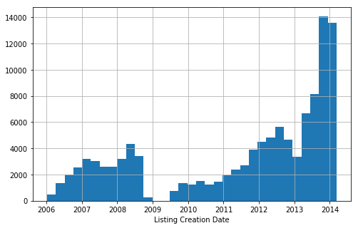

```
count                         112910
unique                        112908
top       2013-06-03 17:27:50.540000
freq                               2
first     2006-01-06 15:21:19.047000
last      2014-03-10 12:20:53.760000
Name: ListingCreationDate, dtype: object
```

```python
plt.figure(figsize=[8, 5])
loan_master['ListingCreationDate'].hist(bins=33)
plt.xlabel('Listing Creation Date')
plt.show()
print(loan_master.ListingCreationDate.describe());
```

Next, let us look at loan closing dates:

### Closed Date (Definition)

> is applicable for Cancelled, Completed, Chargedoff and Defaulted loan statuses.

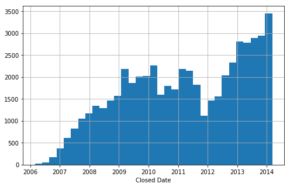

```
count                   54920
unique                   2792
top       2014-03-04 00:00:00
freq                      105
first     2006-02-27 00:00:00
last      2014-03-10 00:00:00
Name: ClosedDate, dtype: object
```

```python
plt.figure(figsize=[8, 5])
loan_master['ClosedDate'].hist(bins=33)
plt.xlabel('Closed Date')
plt.show()
print(loan_master.ClosedDate.describe());
```

About half of the loans (54,920) in the dataframe have closed already. The variable **`ClosedDate`** includes loans that have completed without credit event (i.e. matured), cancelled loans and loans that were in delinquency for some time (i.e. charged-off and defaulted loans). The number of quarterly observations starts from a very low base in 2006 to a first peak of approx. 2000 in each quarter of 2009. After some volatility in 2010 and 2011, growth in quarterly loan closings picked up again in 2012. In 2013 quarterly loan closings reached a level of approx. 2800, growing to approx. 3500 in 1Q 2014.

Next, let us look at another variable in datetime format.

### First Recorded Credit Line (Description)

> The date the first credit line was opened.

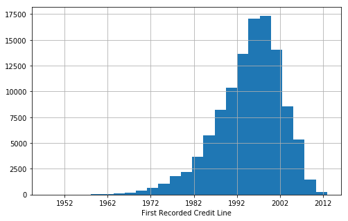

```
count                  112238
unique                  11585
top       1993-12-01 00:00:00
freq                      185
first     1947-08-24 00:00:00
last      2012-12-22 00:00:00
Name: FirstRecordedCreditLine, dtype: object
```

```python
plt.figure(figsize=[8, 5])
loan_master['FirstRecordedCreditLine'].hist(bins=25)
plt.xlabel('First Recorded Credit Line')
plt.show()
print(loan_master.FirstRecordedCreditLine.describe());
```

The variable **`FirstRecordedCreditLine`** is an indication for the age distribution of borrowers. If we assume that most borrowers received their first credit line in their early 20s, and most observations occurred between 1982 and 2002, then most borrowers were born 1962-1982. The number of much older borrowers is relatively small.

What is the level of indebtedness of Prosper's borrowers?

### Debt To Income Ratio (Definition)

> The debt to income ratio of the borrower at the time the credit profile was pulled. This value is Null if the debt to income ratio is not available. This value is capped at 10.01 (any debt to income ratio larger than 1000% will be returned as 1001%).

According to Prosper's current guidelines new loans will only be granted to borrowers with:

> - Debt‐to‐income ratio below 50%

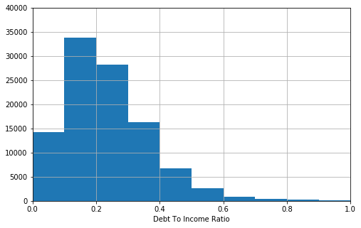

```
count    104449.000000
mean          0.276109
std           0.553848
min           0.000000
25%           0.140000
50%           0.220000
75%           0.320000
max          10.010000
Name: DebtToIncomeRatio, dtype: float64
87.9 % of borrowers have a ratio of 0.5 or below.
12.6 % of borrowers have a ratio of 0.1 or below
 1.0 % of borrowers have a ratio of 1.0 or higher
```

```python
plt.figure(figsize=[8, 5])
loan_master['DebtToIncomeRatio'].hist(bins=100)
plt.xlabel('Debt To Income Ratio')
plt.ylim(0,40000)
plt.xlim(0,1)
plt.show();
print(loan_master.DebtToIncomeRatio.describe())
print(round(loan_master[loan_master['DebtToIncomeRatio'] <= 0.5].shape[0] / \
            loan_master['DebtToIncomeRatio'].shape[0],3)*100,'% of borrowers have a ratio of 0.5 or below.')
print(round(loan_master[loan_master['DebtToIncomeRatio'] <= 0.1].shape[0] / \
            loan_master['DebtToIncomeRatio'].shape[0],3)*100,'% of borrowers have a ratio of 0.1 or below')
print('',round(loan_master[loan_master['DebtToIncomeRatio'] > 1.0].shape[0] / \
            loan_master['DebtToIncomeRatio'].shape[0],2)*100,'% of borrowers have a ratio of 1.0 or higher')
```

Next, let us turn to a variable containing categorical data voluntarily provided by the borrowers.

### Listing Category (numeric) (Definition)

> The category of the listing that the borrower selected when posting their listing: 0 - Not Available, 1 - Debt Consolidation, 2 - Home Improvement, 3 - Business, 4 - Personal Loan, 5 - Student Use, 6 - Auto, 7- Other, 8 - Baby&Adoption, 9 - Boat, 10 - Cosmetic Procedure, 11 - Engagement Ring, 12 - Green Loans, 13 - Household Expenses, 14 - Large Purchases, 15 - Medical/Dental, 16 - Motorcycle, 17 - RV, 18 - Taxes, 19 - Vacation, 20 - Wedding Loans

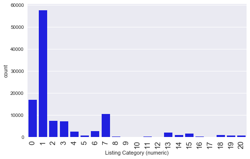

```python
sb.set(style="darkgrid")
binsize = 0.5
bins = np.arange(0, 8, binsize)
plt.figure(figsize=[8, 5])
sb.countplot(data = loan_master, x = 'ListingCategory (numeric)', color="b" )
plt.xlabel('Listing Category (numeric)')
plt.xticks(rotation=90, fontsize=15)
plt.show()
```

Let us now turn to a categorical variable that borrowers need to provide during the loan application process.

### Income Range (Definition)

> The income range of the borrower at the time the listing was created.

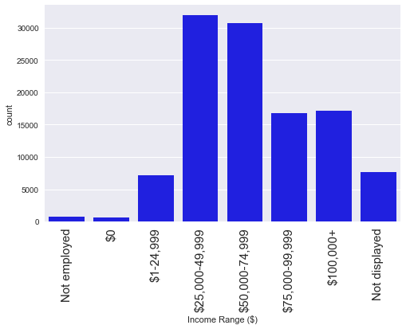

```
$25,000-49,999    31900
$50,000-74,999    30704
$100,000+         17172
$75,000-99,999    16763
Not displayed      7716
$1-24,999          7228
Not employed        806
$0                  621
Name: IncomeRange, dtype: int64
```

```python
sb.set(style="darkgrid")
binsize = 0.5
bins = np.arange(0, 8, binsize)
plt.figure(figsize=[8, 5])
sb.countplot(data = loan_master, x = 'IncomeRange', color = "b", order=['Not employed','$0','$1-24,999','$25,000-49,999','$50,000-74,999','$75,000-99,999','$100,000+', 'Not displayed'])
plt.xlabel('Income Range ($)')
plt.xticks(rotation=90, fontsize=15)
plt.show()
loan_master.IncomeRange.value_counts()
```

The variable **`IncomeRange`** shows that most borrowers have an annual income between USD25,000 and USD75,000. The share of high income borrowers USD75,000-99,000 and USD100,000+ is relatively high as well, while the share of borrowers with income below USD25,000 is much smaller. However, there are approx. 7700 loans with income range 'Not displayed'.

Let us now look at another categorical variable provided by the borrower.

### Employment Status (Definition)

> The employment status of the borrower at the time they posted the listing.

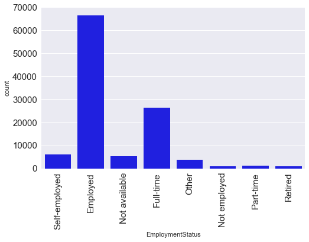

```
Employed         0.601608
Full-time        0.237170
Self-employed    0.054644
Not available    0.048310
Other            0.033809
Part-time        0.009767
Not employed     0.007544
Retired          0.007147
Name: EmploymentStatus, dtype: float64
```

```python
sb.set(style="darkgrid")
plt.figure(figsize=[8, 5])
sb.countplot(data = loan_master, x = 'EmploymentStatus', color = "b");
plt.xticks(rotation=90, fontsize=15)
plt.yticks(rotation=0, fontsize=15)
plt.show()
loan_master.EmploymentStatus.value_counts(normalize=True)
```

The distribution of **`Employment Status`** shows that 60% of borrowers are "Employed" and a further 24% work "Full-time". While approx. 5% are "Self-employed", the share of "Part-time", "Not employed" and "Retired" is at or below 1%. Apparently, Prosper loans are hardly an option for student loans. Nevertheless, "Others" make up 3% and "Not available" is 5% of observations.

What are the professions of the borrowers?

### Occupation (Definition)

> The Occupation selected by the Borrower at the time they created the listing.

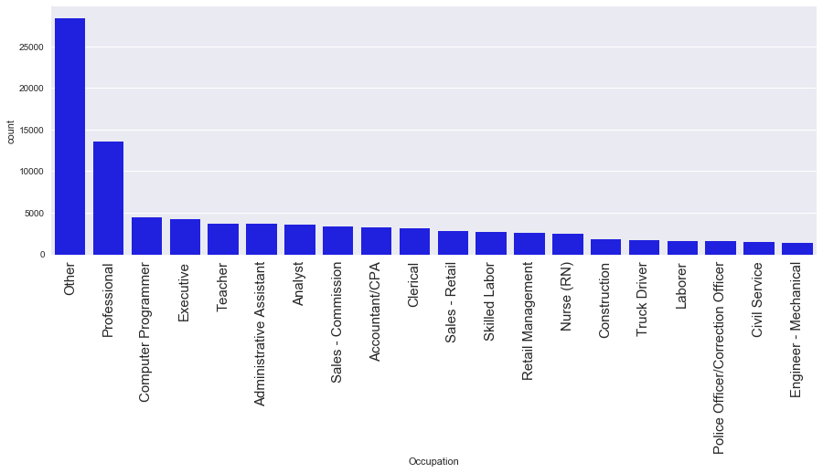

```
Top 20 in %
```

```
Other                                0.259510
Professional                         0.123467
Computer Programmer                  0.040519
Executive                            0.039084
Teacher                              0.034038
Administrative Assistant             0.033563
Analyst                              0.032622
Sales - Commission                   0.031205
Accountant/CPA                       0.029304
Clerical                             0.028636
Sales - Retail                       0.025383
Skilled Labor                        0.024862
Retail Management                    0.023554
Nurse (RN)                           0.022604
Construction                         0.016233
Truck Driver                         0.015200
Laborer                              0.014423
Police Officer/Correction Officer    0.014259
Civil Service                        0.013180
Engineer - Mechanical                0.012742
Name: Occupation, dtype: float64
```

```python
sb.set(style="darkgrid")
binsize = 0.5
bins = np.arange(0, 8, binsize)
plt.figure(figsize=[15, 5])
sb.countplot(data = loan_master, x = 'Occupation', color = "b", \
             order=['Other','Professional','Computer Programmer', 'Executive','Teacher','Administrative Assistant','Analyst',\
                   'Sales - Commission','Accountant/CPA','Clerical','Sales - Retail','Skilled Labor','Retail Management',\
                    'Nurse (RN)','Construction','Truck Driver','Laborer','Police Officer/Correction Officer',\
                    'Civil Service','Engineer - Mechanical'])

plt.xlabel('Occupation')
plt.xticks(rotation=90, fontsize=15)
plt.show()
print('Top 20 in %')
loan_master.Occupation.value_counts(normalize=True).head(20) # show share of top 20 Occupations
```

Prosper borrowers come from a wide variety of professions. Most borrowers selected "Professional" (12.3%), "Computer Programmer" (4.0%) or "Executive" (3.9%), followed by "Teacher" (3.4%), "Administrative Assistant" (3.4%), "Analyst" (3.3%) and "Sales - Commission" (3.1%). However, about a quarter of borrowers do not show a profession and choose "Others".

Where are the borrowers domiciled?

### BorrowerState (Definition)

> The two letter abbreviation of the state of the address of the borrower at the time the Listing was created.

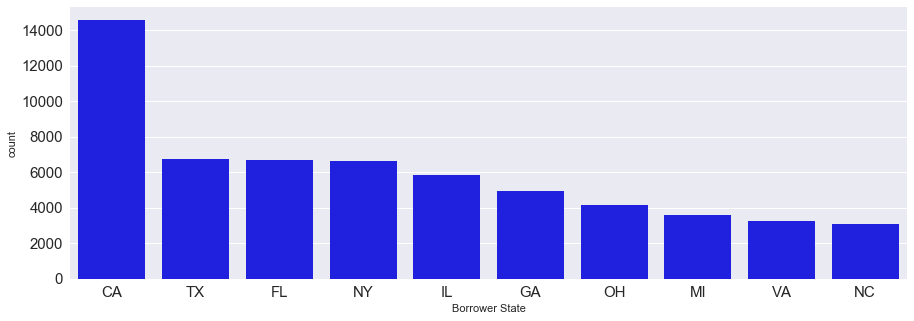

```
Top 10 in %
CA    0.135692
TX    0.063005
FL    0.062028
NY    0.061916
IL    0.054599
GA    0.046276
OH    0.038736
MI    0.033187
VA    0.030246
NC    0.028514
Name: BorrowerState, dtype: float64

Top 10 make up:  0.5541984732824429
```

```python
sb.set(style="darkgrid")
binsize = 0.5
bins = np.arange(0, 8, binsize)
plt.figure(figsize=[15, 5])
sb.countplot(data = loan_master, x = 'BorrowerState', color = "b",\
             order=['CA','TX','FL','NY','IL','GA','OH','MI','VA','NC'])

plt.xlabel('Borrower State')
plt.xticks(rotation=0, fontsize=15)
plt.yticks(rotation=0, fontsize=15)
plt.show()
print('Top 10 in %')
print(loan_master.BorrowerState.value_counts(normalize=True).head(10))
print()
print('Top 10 make up: ', loan_master.BorrowerState.value_counts(normalize=True).head(10).sum())
```

```python
loan_master.BorrowerState.describe()
```

```
count     107420
unique        51
top           CA
freq       14576
Name: BorrowerState, dtype: object
```

The chart shows the Top 10 states where Proper’s borrowers are domiciled. The company's headquarters are in San Francisco, and most borrowers live in California, followed by Texas, Florida, New York and Illinois. The Prosper data comprises of borrowers from all 50 states and from Washington D.C., but the top 10 states make up 55% of the total.

Next, let us look at the evaluation of borrowers' credit risk. Prosper has provided an increasing amount of information about prospective borrowers over time, while also making various changes to its credit policy. Prior to its 2008 'quiet period' and 2009 SEC registration, the company provided **Credit Grades** and other credit information about its prospective lenders. Following the SEC registration, the company created a new model that determined **Prosper Ratings** instead. Additionally, new prospective borrowers were required to have a FICO 8 credit score of at least 640, while returning borrowers only need a score of 600 to request a loan. Since its SEC registration in 2009, Prosper has provided a proprietary "Prosper Rating" for prospective borrowers based on the company's estimation of that borrower's **"estimated loss rate."** According to the company, that figure is "determined by two scores: (1) the credit score, obtained from an official credit reporting agency, and (2) the Prosper Score, figured in-house based on the Prosper population." Prosper Ratings, from lowest-risk to highest-risk, are labelled AA, A, B, C, D, E, and HR ("High Risk").

Source: Wikipedia

### Rating (Definition)

> The variables **`Rating`** and **`Rating_numeric`** are a combination of the new **ProsperRating (Alpha)** and the old **CreditGrade**.

> The scale division of **`Rating`** and the mapping into **`Rating_numeric`** is as follow:
> - N/A - 0 , HR - 1 , E - 2 , D - 3 , C 4 , B - 5 , A - 6 , AA -7 ,nc -8 , hr -9, e -10, d -11 ,c -12 ,b -13 ,a -14 ,aa -15

> **ProsperRating (Alpha)** ('AA','A','B','C','D','E','HR','NR') Introduced 2009
> - The Prosper Rating assigned at the time the listing was created between AA - HR. Applicable for loans originated after July 2009.

> **CreditGrade** ('aa','a','b','c','d','e','hr','nc') Used pre 2009. Displayed here in lower case printing
> - The Credit rating that was assigned at the time the listing went live. Applicable for listings pre-2009 period and will only be populated for those listings.

Let us have a look at the distribution of Rating.

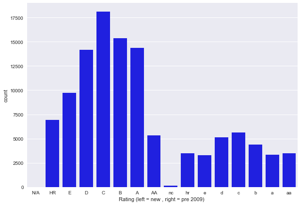

```
C     0.160269
B     0.136108
A     0.127447
D     0.125498
E     0.086051
HR    0.061261
c     0.050004
AA    0.047161
d     0.045629
b     0.038854
hr    0.031051
aa    0.030954
a     0.029351
e     0.029121
nc    0.001240
Name: Rating, dtype: float64
```

```python
binsize = 0.5
bins = np.arange(0, 8, binsize)
sb.set(style="darkgrid")
plt.figure(figsize=[10, 7])
sb.countplot(data = loan_master, x = 'Rating', color = "b", order=['N/A','HR','E','D','C','B','A','AA','nc','hr','e','d','c','b','a','aa'])

plt.xlabel('Rating (left = new , right = pre 2009) ')
plt.show()
loan_master.Rating.value_counts(normalize=True)
```

The distribution of **`Rating`** highlights the different rating methodologies between **ProsperRating** printed in capital letters and the former **CreditGrade** printed here in lower case. The distribution of the ProsperRating has a bell shape centred around Rating class "C", with significantly lower numbers of loans rated high risk-"HR" and top quality-"AA". In contrast, the former CreditGrade is also centred around "c", but with fat-tails on both ends of the credit quality spectrum. The number of top rated Creditgrade-"aa" loans exceeds "a" and "e" and is almost equal to the number of high risk loans with CreditGrade-"hr".

Now, let us turn to the new propriatary ProsperScore that is calculated in-house based on the Prosper population.

### ProsperScore (Definition)

> A custom risk score built using historical Prosper data. The score ranges from 1-10, with 10 being the best, or lowest risk score. Applicable for loans originated after July 2009.

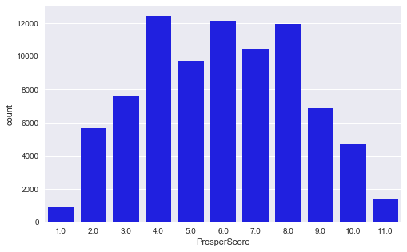

```
4.0     0.148163
6.0     0.144805
8.0     0.142328
7.0     0.124896
5.0     0.115882
3.0     0.090079
9.0     0.081744
2.0     0.067943
10.0    0.055857
11.0    0.017039
1.0     0.011264
Name: ProsperScore, dtype: float64
```

```python
# Question: Why are there observations with ProsperScore > 10?

sb.set(style="darkgrid")
binsize = 0.5
bins = np.arange(1, 10, binsize)
plt.figure(figsize=[8, 5])
sb.countplot(data = loan_master, x = 'ProsperScore', color = "b")
plt.xlabel('ProsperScore')
plt.show()
loan_master.ProsperScore.value_counts(normalize=True)
```

The variable **`ProsperScore`** has a multimodal distribution with 3 modes at "4","6" and "8". The shape of the distribution is symmetric, with roughly equal numbers of observations scored "5" , "7" and "3" and "9". The number of loans with a score of "2" is roughly equal to the number of loans scored "10" and "11" (acording to the description "10" is already the best score).

Next, let us look at the interest rates of the loans.

From 2006 to 2009 Prosper operated a variable rate model. Prosper acted as an eBay-style online auction marketplace, with lenders and borrowers ultimately determining loan rates using a **Dutch auction-like system**. Effective December 19, 2010, Prosper filed a new prospectus with the SEC, **changing its business model to use pre-set rates** determined solely by Prosper based on a formula evaluating each prospective borrower's credit risk. Under the new approach, lenders no longer determine the loan rate via price discovery in an auction. Instead, they simply choose whether to invest at the rate which Proper’s loan pricing algorithm assigns to the loan after it analyses the borrower's credit report and financial information. (Source: Wikipeadia)

### Borrower APR (Definition)

> The Borrower's Annual Percentage Rate (APR) for the loan.

> APR is the combination of the nominal interest rate and any other costs or fees involved in procuring the loan. As a result, an APR tends to be higher than a loan's nominal interest rate. (Source: Wikipeadia)

> **Fees**

> There are no fees for posting a borrower listing on Prosper. Fees are only charged if your loan is funded and money is transferred to you.

> **Closing fee**

> The closing fee is a percentage of the amount borrowed and varies by Prosper Rating:
> - 1 year 3 year 5 year

> AA
> - 0.50% 1.95% 4.95%

> A
> - 1.95% 3.95% 4.95%

> B
> - 2.95% 4.95% 4.95%

> C -HR
> - 3.95% 4.95% 4.95%

> The closing fee is taken from the loan immediately, before loan proceeds are transferred to your account. This means that if you're using your Prosper loan to purchase something specific (like kitchen remodeling), make sure you ask for enough to cover both the remodeling project and the closing fee.

> Source: www.prosper.com/loans/rates-and-fees

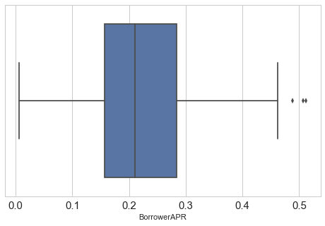

```
count    112910.000000
mean          0.193003
std           0.074890
min           0.000000
25%           0.134500
50%           0.184000
75%           0.250600
max           0.497500
Name: BorrowerRate, dtype: float64
```

```python
sb.set(context='notebook', style='whitegrid', palette='deep', font='sans-serif', font_scale=1, rc=None)
plt.figure(figsize=[8, 5])
sb.boxplot(loan_master['BorrowerAPR'])
plt.xticks(rotation=0, fontsize=15)
plt.yticks(rotation=0, fontsize=15)
plt.show()
print(loan_master.BorrowerRate.describe());
```

What is the term to maturity of the loans?

### Term (Definition)

> The length of the loan expressed in months.

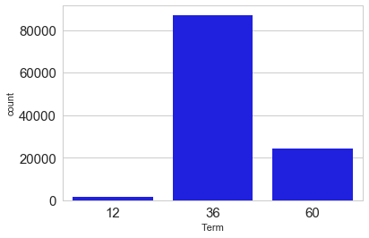

```
36    0.771136
60    0.214578
12    0.014286
Name: Term, dtype: float64
```

```python
sb.countplot(data = loan_master, x = 'Term', color='blue')
plt.xticks(rotation=0, fontsize=15)
plt.yticks(rotation=0, fontsize=15)
plt.show()
loan_master.Term.value_counts(normalize=True)
```

About 77% of the loans have a term-to-maturity of 3-years and 21.5% have a term of 5-years. Only 1.5% of loans have a 1-year term at origination.

Now, let us look at the size of the loans.

### Loan Original Amount (Definition)

> The origination amount of the loan.

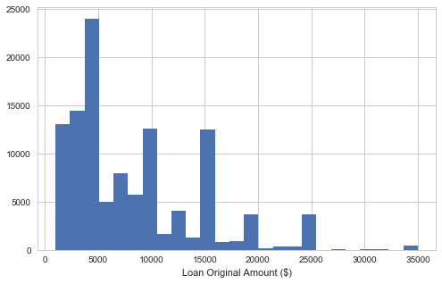

```
count    112910.000000
mean       8320.556735
std        6238.248319
min        1000.000000
25%        4000.000000
50%        6300.000000
75%       12000.000000
max       35000.000000
Name: LoanOriginalAmount, dtype: float64
```

```python
plt.figure(figsize=[8, 5])
loan_master['LoanOriginalAmount'].hist(bins=25)
plt.xlabel('Loan Original Amount ($)')
plt.show()
print(loan_master.LoanOriginalAmount.describe());
```

The chart shows the distribution of the variable **`LoanOriginalAmount`**. The median amount is USD 6,300 and the 1st and 3rd quartile are USD 4,000 and USD 12,000 , respectively. The distribution has a strong positive skew with a mean loan amount of USD 8,320 ( >USD 2,000 above median) and a max. loan amount of USD 35,000.

How does the size of the loans correspond to monthly loan payments?

### Monthly Loan Payment (Definition)

> The scheduled monthly loan payment.

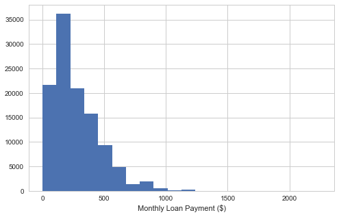

```
count    112910.000000
mean        272.114754
std         192.574655
min           0.000000
25%         131.180000
50%         217.650000
75%         370.620000
max        2251.510000
Name: MonthlyLoanPayment, dtype: float64
```

```python
plt.figure(figsize=[8, 5])
loan_master['MonthlyLoanPayment'].hist(bins=20)
plt.xlabel('Monthly Loan Payment ($)')
plt.show()
print(loan_master.MonthlyLoanPayment.describe());
```

The chart shows the distribution of the variable **`MonthlyLoanPayment`** (in USD). The median is USD 218 and the 1st and 3rd quartile are USD 131 and USD 370, respectively. The distribution has a positive skew with a mean monthly payment of USD 272 ( >USD 50 above median) and a max. monthly payment of USD 2,252.

Let us turn to the status of the loans:

### LoanStatus (Definition)

> The current status of the loan: Cancelled, Chargedoff, Completed, Current, Defaulted, FinalPaymentInProgress, PastDue. The PastDue status will be accompanied by a delinquency bucket.
> - A loan is considered **“Charged-off”** after a borrower misses 5 consecutive monthly payments. At that point, the loan is considered unlikely to be repaid. If a Prosper loan is charged-off, the full loan balance will be due immediately—including all unpaid fees, interest, and principal. In other words, the borrower is not just required to make overdue payments, he of she is expected to pay the loan in full. A charged-off loan will appear on the borrowers' credit report. No additional interest or fees will accrue on the past due balance.
> - Loans that are in **"Default"** are loans for which borrowers have failed to make payments for an extended period of time.

Let us define variables in Python that hold the number of observations of each category of **`LoanStatus`**.

```python
Cancelled              = (loan_master[loan_master['LoanStatus'] == 'Cancelled'].shape[0])
Chargedoff             = (loan_master[loan_master['LoanStatus'] == 'Chargedoff'].shape[0])
Completed              = (loan_master[loan_master['LoanStatus'] == 'Completed'].shape[0])
Current                = (loan_master[loan_master['LoanStatus'] == 'Current'].shape[0])
Defaulted              = (loan_master[loan_master['LoanStatus'] == 'Defaulted'].shape[0])
FinalPaymentInProgress = (loan_master[loan_master['LoanStatus'] == 'FinalPaymentInProgress'].shape[0])
PastDue                = loan_master.shape[0]- Cancelled-Chargedoff-Completed-Current-Defaulted-FinalPaymentInProgress
```

What is the distribution of **`LoanStatus`** by its categories.

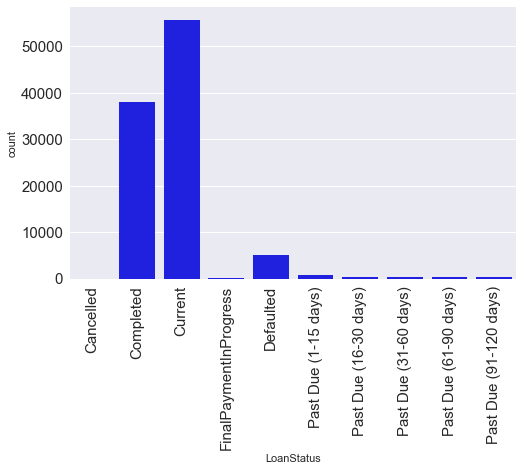

```
Cancelled                 : 0.004 %
Chargedoff                : 10.62 %
Completed                 : 33.58 %
Current                   : 49.36 %
Defaulted                 :  4.44 %
Final Payment In Progress :  0.18 %
PastDue                   :  1.82 %
```

```python
sb.set(style="darkgrid")
plt.figure(figsize=[8, 5])
sb.countplot(data = loan_master, x = 'LoanStatus', color = "b" \
             , order=['Cancelled','Completed','Current','FinalPaymentInProgress',\
                      'Defaulted','Past Due (1-15 days)','Past Due (16-30 days)','Past Due (31-60 days)',\
                      'Past Due (61-90 days)','Past Due (91-120 days)']);
plt.xticks(rotation=90, fontsize=15)
plt.yticks(rotation=0, fontsize=15)
plt.show()

print('Cancelled                 :', np.round(Cancelled               / loan_master.shape[0]*100,3),'%')
print('Chargedoff                :', np.round(Chargedoff              / loan_master.shape[0]*100,2),'%')
print('Completed                 :', np.round(Completed               / loan_master.shape[0]*100,2),'%')
print('Current                   :', np.round(Current                 / loan_master.shape[0]*100,2),'%')
print('Defaulted                 : ', np.round(Defaulted              / loan_master.shape[0]*100,2),'%')
print('Final Payment In Progress : ', np.round(FinalPaymentInProgress / loan_master.shape[0]*100,2),'%')
print('PastDue                   : ', np.round(PastDue                / loan_master.shape[0]*100,2),'%')
```

About half of loans in the dataframe have a status of 'current' and the borrowers keep paying interest and fees in a timely manner. About 15% of the loans were in some form of delinquency and a further 1.8% are currently overdue. One-third of the loans in the dataframe have completed already without a credit impairment (i.e. matured).

Next, we introduce other variables we will need later on. Let us visualize the distribution of the variables and make sure there are no observations with NANs.

### LP_Gross Principal Loss (Definition)

> The gross charged off amount of the loan.

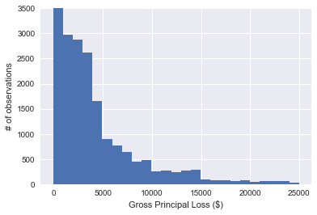

```
0
```

```python
loan_master['LP_GrossPrincipalLoss'].hist(bins=25)
plt.ylim((0, 3500))
plt.xlabel('Gross Principal Loss ($)')
plt.ylabel('# of observations')
plt.show()

loan_master['LP_GrossPrincipalLoss'].isna().sum()
```

The variable **`LP_GrossPrincipalLoss`** has an exponential distribution with many observations at low USD amounts and very few observations at high USD amounts. Most observations have an amount of 0 USD because most of the loans have not defaulted or chargedoff.

### LP_NetPrincipal Loss (Definition)

> The principal that remains uncollected after any recoveries.

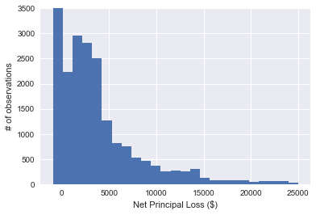

```
0
```

```python
loan_master['LP_NetPrincipalLoss'].hist(bins=25)
plt.ylim((0, 3500))
plt.xlabel('Net Principal Loss ($)')
plt.ylabel('# of observations')
plt.show()

loan_master['LP_NetPrincipalLoss'].isna().sum()
```

The variable **`LP_NetPrincipalLoss`** has an exponential distribution with many observations at low USD amounts and very few observations at high USD amounts. Most observations have an amount of 0 USD because most of the loans have not defaulted or chargedoff.

The distribution is very similar to Gross Principal Loss.

### LP_NonPrincipal Recovery payments (Definition)

> The interest and fee component of any recovery payments. The current payment policy applies payments in the following order: Fees, interest, principal.

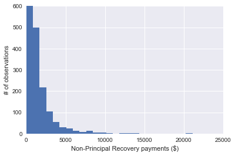

```
0
```

```python
loan_master['LP_NonPrincipalRecoverypayments'].hist(bins=25)
plt.xlim((0, 25000))
plt.ylim((0, 600))
plt.xlabel('Non-Principal Recovery payments ($)')
plt.ylabel('# of observations')
plt.show()

loan_master['LP_NonPrincipalRecoverypayments'].isna().sum()
```

The variable **`LP_NonPrincipalRecoverypayments`** has an exponential distribution with many observations at low USD amounts and very few observations at high USD amounts. Most observations have an amount of 0 USD because most of the loans have not defaulted or chargedoff.

### LP_Customer Principal Payments (Definition)

> Pre charge-off cumulative principal payments made by the borrower on the loan. If the loan has charged off, this value will exclude any recoveries.

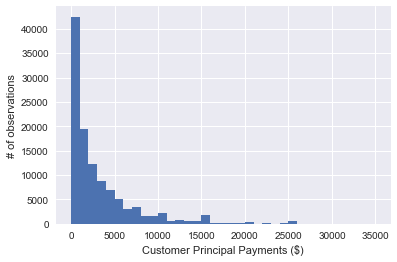

```
count    112910.000000
mean       3124.278532
std        4077.884486
min           0.000000
25%         511.552500
50%        1609.725000
75%        4000.000000
max       35000.000000
Name: LP_CustomerPrincipalPayments, dtype: float64
```

```python
loan_master['LP_CustomerPrincipalPayments'].hist(bins=35)
plt.xlabel('Customer Principal Payments ($)')
plt.ylabel('# of observations')
plt.show()

loan_master['LP_CustomerPrincipalPayments'].isna().sum()
loan_master['LP_CustomerPrincipalPayments'].describe()
```

The variable **`LP_CustomerPrincipalPayments`** has an exponential distribution with many observations at low USD amounts and very few observations at high USD amounts. The mean Customer Principal Payments in USD 3,124 , the median USD 1,610 and USD 512 and USD 4,000 are the 25% and 75% quartiles, respectively.

### </font> Finding

> Prosper Loans are amortizing.

What Is an Amortized Loan?

An amortized loan is a loan with scheduled periodic payments that are applied to both principal and interest. An amortized loan payment first pays off the relevant interest expense for the period, after which the remainder of the payment reduces the principal. Common amortized loans include auto loans, home loans, and personal loans from a bank for small projects or debt consolidation. Source ( investopedia.com )

### LP_Interest and Fees (Definition)

> Pre charge-off cumulative interest and fees paid by the borrower. If the loan has charged off, this value will exclude any recoveries.

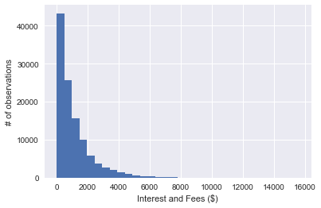

```
0
```

```python
loan_master['LP_InterestandFees'].hist(bins=32)
plt.xlabel('Interest and Fees ($)')
plt.ylabel('# of observations')
plt.show()

loan_master['LP_InterestandFees'].isna().sum()
```

### LP_Customer Payments (Definition)

> Pre charge-off cumulative gross payments made by the borrower on the loan. If the loan has charged off, this value will exclude any recoveries.

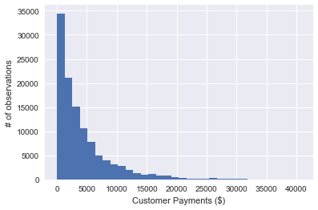

```
0
```

```python
loan_master['LP_CustomerPayments'].hist(bins=32)
plt.xlabel('Customer Payments ($)')
plt.ylabel('# of observations')
plt.show()

loan_master['LP_CustomerPayments'].isna().sum()
```

### LP_Service Fees (Definition)

> Cumulative service fees paid by the investors who have invested in the loan.

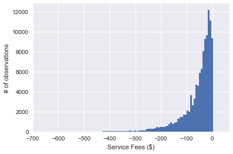

```
0
```

```python
loan_master['LP_ServiceFees'].hist(bins=100)
plt.xlabel('Service Fees ($)')
plt.ylabel('# of observations')
plt.show()

loan_master['LP_ServiceFees'].isna().sum()
```

The variable **`LP_ServiceFees`** has an exponential distribution only with negative values. Most observations have Service Fee Payments between 0 and -100 USD.

### LP_CollectionFees (Definition)

> Cumulative collection fees paid by the investors who have invested in the loan.

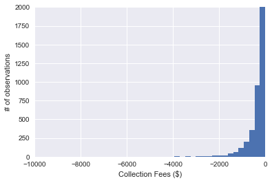

```
0
```

```
-9274.75
```

```python
loan_master['LP_CollectionFees'].hist(bins=40)
plt.xlim((-10000, 0))
plt.ylim((0, 2000))
plt.xlabel('Collection Fees ($)')
plt.ylabel('# of observations')
plt.show();

print(loan_master['LP_CollectionFees'].isna().sum())
loan_master['LP_CollectionFees'].min()
```

The variable **`LP_CollectionFees`** has an exponential distribution with negative values. Most observations have Collection Fee Payments between 0 and -500 USD, but the largest Collection Fee Payment is -9,275 USD.

Let us look at the sums of the variables over all observations (i.e. rows) in the dataframe.

```python
print('LoanOriginalAmount              :', round(loan_master['LoanOriginalAmount'].sum()/1000000,1),'million USD')
print()
print('LP_GrossPrincipalLoss           : ', round(loan_master['LP_GrossPrincipalLoss'].sum()/1000000,1),'million USD','  ', \
     round(loan_master['LP_GrossPrincipalLoss'].sum()/loan_master['LoanOriginalAmount'].sum(),2)*100,'% of Loan Original Amount')
print('LP_NetPrincipalLoss             : ', round(loan_master['LP_NetPrincipalLoss'].sum()/1000000,1),'million USD')
print('Principal recovered             :  ', round((loan_master['LP_GrossPrincipalLoss'].sum() - loan_master['LP_NetPrincipalLoss'].sum())/1000000,1),'million USD')
print('LP_NonPrincipalRecoverypayments :  ', round(loan_master['LP_NonPrincipalRecoverypayments'].sum()/1000000,1),'million USD')
print()
print('LP_CustomerPrincipalPayments    :', round(loan_master['LP_CustomerPrincipalPayments'].sum()/1000000,1),'million USD',\
     ' ',round(loan_master['LP_CustomerPrincipalPayments'].sum()/loan_master['LoanOriginalAmount'].sum(),2)*100,'% of Loan Original Amount')
print('LP_InterestandFees              :', round(loan_master['LP_InterestandFees'].sum()/1000000,1),'million USD')
print('LP_CustomerPayments             :', round(loan_master['LP_CustomerPayments'].sum()/1000000,1),'million USD')
print()
print('LP_ServiceFees                  : ', round(loan_master['LP_ServiceFees'].sum()/1000000,1),'million USD   ', \
     round(loan_master['LP_ServiceFees'].sum() / loan_master['LoanOriginalAmount'].sum(),4)*100,'% of Loan Original Amount')

print('LP_CollectionFees               : ', round(loan_master['LP_CollectionFees'].sum()/1000000,1),'million USD','  ', \
     round(loan_master['LP_CollectionFees'].sum()/loan_master['LoanOriginalAmount'].sum(),3)*100,'%  of Loan Original Amount')
```

```
LoanOriginalAmount              : 939.5 million USD

LP_GrossPrincipalLoss           :  79.8 million USD    8.0 % of Loan Original Amount
LP_NetPrincipalLoss             :  77.6 million USD
Principal recovered             :   2.2 million USD
LP_NonPrincipalRecoverypayments :   2.9 million USD

LP_CustomerPrincipalPayments    : 352.8 million USD   38.0 % of Loan Original Amount
LP_InterestandFees              : 122.4 million USD
LP_CustomerPayments             : 475.2 million USD

LP_ServiceFees                  :  -6.2 million USD    -0.66 % of Loan Original Amount
LP_CollectionFees               :  -1.6 million USD    -0.2 %  of Loan Original Amount
```

The total sum of the loan amounts is USD 939.5 million, and 79.8 million is the Gross Principal Loss from loans in delinquency. However, USD 2.9 million of Non-Principal Recovery payments were received from borrowers in delinquency and the Net Principal Loss of USD 77.6 million is USD 2.2 million smaller than the Gross Principal Loss (i.e. Principal recovered). Therefore, the total recovery value from loans in delinquency is USD 5.0 million or 6.3% of Gross Principal Loss.

### RecoveryRatio (average) (Definition)

$$RecoveryRatio=\sum_{i=1}^n \frac{RecoveryValue}{GrossPrincipalLoss}$$

> with n = Number of loans in the dataframe

```python
Recovery_value = ( loan_master['LP_GrossPrincipalLoss'].sum() - loan_master['LP_NetPrincipalLoss'].sum() \
           + loan_master['LP_NonPrincipalRecoverypayments'].sum() )

Recovery_ratio = Recovery_value / loan_master['LP_GrossPrincipalLoss'].sum()

Recovery_ratio
```

```
0.06307274588008648
```

### Back of the envelope P&L calculation

Customer Principal Payments of 352.8 million represent 38% of Loan Original Amount. Apparently, this variable comprises of all final payments from completed loans and from principal recovered in delinquency. Furthermore, there could be a small share of amortizing loans.

Interest and Fees of USD 122.4 million exceed the Gross Principal Loss of USD 79.8 million. The difference of USD 42.6 together with the Recovery value of USD 5.1 million represent the realized profit for the investors before fees.

> USD 47.7 million Investors gross profit

> USD -6.2 million Service Fees

> USD -1.6 million Collection Fees

> = USD 39.9 million Investors Profit (net)

Investors in Prosper loans received more money from borrowers than what was lost from loan defaults and charged-offs. Going forward, this profit can turn negative if delinquencies rise. Nevertheless, the 8.25-year time frame 2006- Q1 2014 includes a major recession with elivated delinquency rates.

### Discuss the distribution(s) of your variable(s) of interest. Were there any unusual points? Did you need to perform any transformations?

> About half of loans have a **`LoanStatus`** of 'current' and the borrowers keep paying interest and fees in a timely manner. About 15% of the loans were in some form of delinquency and a further 1.8% are currently overdue. One-third of the loans in the dataframe have completed already without a credit impairment (i.e. matured).

> The distribution of the numerical variable **`BorrowerAPR`** is normal with a positive skew. The mean value is 19.3% and the median is 18.4%. The 1st and 3rd quartile are 13.5% and 25.1%, respectively. Therefore, the shape of the distribution is nearly symetrical with a positive skew (i.e. The right tail is longer; the mass of the distribution is concentrated on the left).

> The distribution of the numerical variable **`LoanOriginalAmount`** has a strong positive skew. The median amount is USD 6,300 and the 1st and 3rd quartile are USD 4,000 and USD 12,000 , respectively. The mean loan amount is USD 8,320 ( >USD 2,000 above median) and the max. loan amount is USD 35,000.

> The distribution categorical variable **`Rating`** highlights the different rating methodologies between **ProsperRating** , introduced in 2009, and the former **CreditGrade**. The distribution of the ProsperRating has a bell shape centred around Rating class "C", with significantly lower numbers of loans rated high risk-"HR" and top quality-"AA". In contrast, the former CreditGrade is also centred around "c", but with fat-tails on both ends of the credit quality spectrum. The number of top rated Creditgrade-"aa" loans exceeds "a" and "e" and is almost equal to the number of high risk loans with CreditGrade-"hr".

## Bivariate Exploration

Let us start by calculating a new variable Profit and Loss **`P&L`** for each loan.

### Profit and Loss (P&L) (Definition)

> For outstanding loans the value of **`P&L`** is equal to the variable **`LP_InterestandFees`** (i.e. interest and fees received so far from the borrower). This way we treat all loans that have not closed yet as 'performing loans' and we do not write-off any principal amount. Therefore, we only realize a loss in the variable **`LoanOriginalAmount`** for loans in delinquency when the variable **`ClosedDate`** shows a date. **`LoanOriginalAmount`** is the amount of the loan at the time of origination. The date of closing is not shown for loans with **`LoanStatus`** = 'Current' , 'FinalPaymentInProgress' , 'Past Due (1-15 days)', 'Past Due (16-30 days)' , 'Past Due (31-60 days)' , 'Past Due (61-90 days)' and 'Past Due (91-120 days)'. A loan is considered "delinquent" when a borrower doesn't make a loan payment on time. Most lenders allow consumers a grace period to make up a missed payment and get their loan out of delinquency. Correspondingly, we ignore loans with interest payments overdue for up to 120 days (i.e **`LoanStatus`** = `Past_Due` ). However, once a loan is delinquent for a certain period of time, it becomes at risk of going into default or being charged-off ( Source: https://www.valuepenguin.com/loans/what-is-a-delinquent-loan ).

> For all loans with a date in **`ClosedDate`** (i.e. **`LoanStatus`** = 'Completed' , 'Cancelled' , 'Defaulted' or 'Chargedoff' ) the variable **`P&L`** is equal to the difference between **`LP_CustomerPayments`** and **`LoanOriginalAmount`**. The variable **`LP_CustomerPayments`** shows the Pre charged-off cumulative gross payments made by the borrower on the loan. If the loan is charged-off, this value will exclude any recoveries. The average recovery value on unsecured consumer loans is very low and we will ignore it in the calculation of **`P&L`**.

> The **`P&L`** for an outstanding loan turns positive as soon as we receive the 1st interest payment from the borrower and interest payments are accumulated further until the loan is closed.

> The **`P&L`** for a closed loan is positive when the sum of payments from the borrower exceeded the principal amount (normally only the case for **`LoanStatus`** = 'Completed'). For simplicity, we ignore cost of capital for the lender or other opportunity costs.

```python
loan_master['LP_CustomerPayments'].isna().sum() # Verify that the variable has no NANs
```

```
0
```

```python
loan_master['LoanOriginalAmount'].isna().sum() # Verify that the variable has no NANs
```

```
0
```

```python
# Populate the variable 'P&L'

loan_master['P&L'] = loan_master['LP_InterestandFees'] # take the value from 'LP_InterestandFees' for every observation

start = timer()
for n in range(loan_master.shape[0]):

    # this returns 'True' if observation [n] is not NAN
    if loan_master["ClosedDate"][n] == loan_master["ClosedDate"][n]:
        # for closed loans the P&L is equal to the difference between Customer Paymensts and the Loan Original Amount
        loan_master["P&L"][n] = loan_master['LP_CustomerPayments'][n] - loan_master['LoanOriginalAmount'][n]
    else:
        continue  # keep the value from 'Interest and Fees' if 'Closed Date' == NAN

end = timer()
```

```python
(end - start)/60 # Takes a very long time to compute
```

```
37.889201846666666
```

Let us calculate a new variable for the Total Return **`TOT`** for each loan.

### Total Return (TOT) (Definition)

> The Total Return of a loan is its **`P&L`** divided by the Loan Original Amount.

```python
loan_master['TOT'] = loan_master['P&L'] / loan_master['LoanOriginalAmount']
```

Let us store the amended dataframe.

```python
loan_master.to_csv(r'loan_master', index=True)
```

Next, we define some useful filters based on the categories of **`LoanStatus`**.

```python
Defaulted_filter              = loan_master[loan_master['LoanStatus']=='Defaulted']
Chargedoff_filter             = loan_master[loan_master['LoanStatus']=='Chargedoff']
Completed_filter              = loan_master[loan_master['LoanStatus']=='Completed']
Current_filter                = loan_master[loan_master['LoanStatus']=='Current']
Matured_filter                = loan_master.query("LoanStatus == 'Completed' or LoanStatus == 'Defaulted' \
                                                              or LoanStatus == 'Chargedoff'")
Cancelled_filter              = loan_master[loan_master['LoanStatus']=='Cancelled']
FinalPaymentInProgress_filter = loan_master[loan_master['LoanStatus']=='FinalPaymentInProgress']

# We ignore the 5 stages of Past_Due (see below)
#                              = loan_master[loan_master['LoanStatus']=='Past Due (1-15 days)']
#                                loan_master[loan_master['LoanStatus']=='Past Due (16-30 days)']
#                                loan_master[loan_master['LoanStatus']=='Past Due (31-60 days)']
#                                loan_master[loan_master['LoanStatus']=='Past Due (61-90 days)']
#                                loan_master[loan_master['LoanStatus']=='Past Due (91-120 days)']
```

We calculate the ratio of **`P&L`** on all defaulted loans to the total principal of all defaulted loans. We do the same for all loans with **`LoanStatus`** = `chargeoff` and `complete`. Furthermore, we add an estimate for the average recovery value based on the **Recovery Ratio** (see Definition) . We could have calculated a recovery value for each loan instead, but some loans in delinquency show `LP_NetPrincipalLoss` entries of 0. In contrast, `LP_GrossPrincipalLoss` show reasonable values for all observations.

`LP_GrossPrincipalLoss` = The gross charged off amount of the loan.

`LP_NetPrincipalLoss` = The principal that remains uncollected after any recoveries.

```python
pL_defaulted        = ((Defaulted_filter['P&L'].sum()   / Defaulted_filter['LoanOriginalAmount'].sum()))
pL_chargedoff       = ((Chargedoff_filter['P&L'].sum() / Chargedoff_filter['LoanOriginalAmount'].sum()))
pL_completed        = ((Completed_filter['P&L'].sum() / Completed_filter['LoanOriginalAmount'].sum()))
pL_current          = ((Current_filter['P&L'].sum() / Current_filter['LoanOriginalAmount'].sum()))
pL_Pf               = ((loan_master['P&L'].sum()   / loan_master['LoanOriginalAmount'].sum()))
pL_Pf_withRecovery  = (((loan_master['P&L'].sum() + Recovery_value )  / loan_master['LoanOriginalAmount'].sum()))
```

We vsiualize our findings in a bar chart.

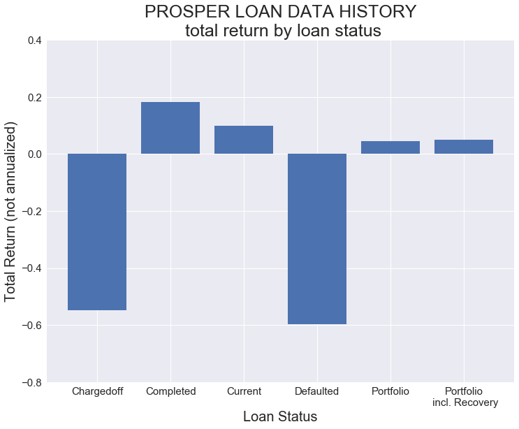

```
Current              :   0.098
Defaulted            :  -0.598
Chargedoff           :  -0.549
Completed            :   0.183
Portfolio            :   0.045
Portfolio
 incl. Recovery      :   0.049997
```

```python
plt.figure(figsize=[12, 9])
plt.title('PROSPER LOAN DATA HISTORY\n total return by loan status', fontsize=25)
data = {'Current'  : pL_current, 'Defaulted': pL_defaulted, 'Chargedoff': pL_chargedoff, \
#        'Recovery': recovery_estimate,\
        'Completed': pL_completed, 'Portfolio': pL_Pf, 'Portfolio\n incl. Recovery': pL_Pf_withRecovery \
         }
names = list(data.keys())
values = list(data.values())
plt.bar(names, values)
plt.xlabel('Loan Status', fontsize=20)
plt.ylabel('Total Return (not annualized)', fontsize=20)
plt.xticks(rotation=0, fontsize=15)
plt.yticks(rotation=0, fontsize=15)
plt.ylim(-0.8,.4)
plt.show();

print('Current              :  ', round(pL_current ,3))
print('Defaulted            : ',  round(pL_defaulted,3))
print('Chargedoff           : ',  round(pL_chargedoff,3))
print('Completed            :  ', round(pL_completed,3))
print('Portfolio            :  ', round(pL_Pf,3))
print('Portfolio\n incl. Recovery      :  ', round(pL_Pf_withRecovery,6))
```

The bar chart shows the realized **Total Return (TOT)** by **Loan Status** for the entire portfolio of Prosper loans in the data base. **Current** loans have already received interest payments of 9.8% of the principal amount outstanding. Here we assume that all those loans will be redeemed in full. The historical total return on all **Completed** loans was +18.3% from earned interest. However, the realized TOT on **Defaulted** loans was -59.8% (i.e. Loss-given-default) because most principal was lost. **Chargedoff** loans show a similar performance of -54.9% (Loss-given-chargedoff). Here we ignore the meagre average recovery estimate of +6.3% of principal calculated earlier.

The **Portfolio** total return is + 4.5% and **Portfolio incl. Recovery** total return is + 5.0%. The meagre average recovery value of unsecured consumer loans does not help much to cushion the negative cash flow impact of defaults and charged offs on the portfolio. However, the magnitude of the portfolio total return is reduced by recent inflows and we should not use it as the sole yardstick for measuring investment performance. The fact that the Prosper loan portfolio shows a positive investment return over an entire credit cycle and that it generates large inflows are both measures of success.

**Investment performance is determined by the magnitude of the total returns by loan status and by the allocation of performing and non-performing loans in the portfolio.**

Next, let us look at the allocation of Gross Principal Loss by Loan Status.

## LP_Gross Principal Loss

> The gross charged off amount of the loan.

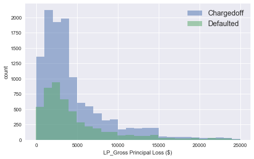

```
Charged-off
count    11986.000000
mean      4664.318988
std       4294.494114
min          0.000000
25%       1818.785000
50%       3349.065000
75%       5958.510000
max      25000.000000
Name: LP_GrossPrincipalLoss, dtype: float64

Defaulted
count     5015.000000
mean      4761.950275
std       4689.979401
min        -94.200000
25%       1759.370000
50%       3152.270000
75%       5996.605000
max      25000.000000
Name: LP_GrossPrincipalLoss, dtype: float64
```

```python
text=['Chargedoff', 'Defaulted']

plt.figure(figsize=[8, 5])
Chargedoff_filter['LP_GrossPrincipalLoss'].hist(bins=25, alpha=0.5)
Defaulted_filter['LP_GrossPrincipalLoss'].hist(bins=25, alpha=0.5)
plt.xlabel('LP_Gross Principal Loss ($)')
plt.ylabel('count')
plt.legend(text, fontsize='large')
plt.show()
print('Charged-off')
print(Chargedoff_filter.LP_GrossPrincipalLoss.describe())
print()
print('Defaulted')
print(Defaulted_filter.LP_GrossPrincipalLoss.describe());
```

The chart shows the two distributions of Gross Principal Loss for all loans with Loan Status 'Charged-off' and 'Defaulted'. The shape of the two distributions is similar, albeit with lower counts for 'Defaulted'.

### </font> Finding

> There is no practical difference between charge-offs and defaults for the investor. Loans with **`LoanStatus`** categorical values 'Charged-off' and 'Defaulted' have a similarly shaped distribution of the variables **`GrossPrincipalLoss`** and **`TOT`**. The Loss-given-default is similar to the Loss-given-chargedoff.

Let us see how credit quality developed over time. How did the numbers of loans created and the composition of `LoanStatus` change from quarter to quarter since Prosper started in 2006? We use the date the listing was created as shown in `ListingCreationDate` to define the vintage of a loan.

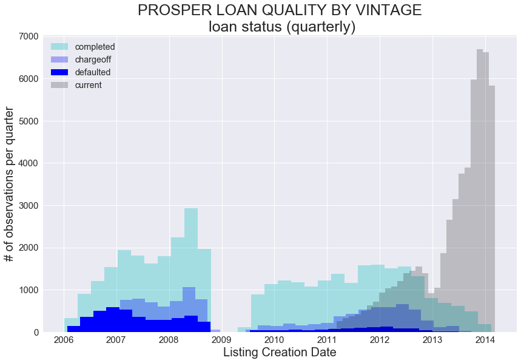

```python
# Description: ListingCreationDate = The date the listing was created.
text=['completed','chargeoff','defaulted','current']
plt.figure(figsize=[14, 9])
plt.title('PROSPER LOAN QUALITY BY VINTAGE\n loan status (quarterly)', fontsize=25)
Completed_filter['ListingCreationDate'].hist(bins=32, alpha=0.3, color='c')
Chargedoff_filter['ListingCreationDate'].hist(bins=32, alpha=0.3, color='b')
Defaulted_filter['ListingCreationDate'].hist(bins=32, alpha=1, color='b')
Current_filter['ListingCreationDate'].hist(bins=32, alpha=0.2, color='k')

plt.legend(text, fontsize='large')
plt.xlabel('Listing Creation Date', fontsize=20)
plt.ylabel('# of observations per quarter', fontsize=20)
plt.xticks(rotation=0, fontsize=15)
plt.yticks(rotation=0, fontsize=15)
plt.show();
```

The chart reveals the dichotomy in the Prosper loan data with different average credit quality before and after the 2008-2009 Financial Crisis. From the start in 2006 Prosper's loan portfolio grew strongly until coming to a complete standstill in late 2008. The filing for Chapter 11 bankruptcy protection by Lehman Brothers on September 15, 2008, brought an end to the period of 'easy credit'. Since its SEC registration in 2009, Prosper has provided a proprietary "Prosper Rating" for prospective borrowers based on the company's estimation of that borrower's "estimated loss rate." (Source: Wikipedia). Correspondingly, the number of defaults is lower in loan vintages post 2009, albeit at lower overall origination activity. However, the number of charge offs has picked up again in the 2011 and 2012 vintages. Since 2012, Prosper shows a strong growth in new loan origination surpassing pre crisis levels.

To get a better understanding for the development of Prosper's loan data credit quality over time we produce a small table `CreditQuality_df´ with annual credit statistics.

```python
lst1=[]
lst2=[]
lst3=[]
lst4=[]
lst5=[]
lst6=[]
lst7=[]
start_dates = ["2006-1-1" , "2007-1-1", "2008-1-1", "2009-1-1", "2010-1-1", "2011-1-1", "2012-1-1", "2013-1-1", "2014-1-1"]
end_dates=["2006-12-31","2007-12-31","2008-12-31","2009-12-31","2010-12-31","2011-12-31","2012-12-31","2013-12-31","2014-12-31"]


for i in range(2015-2006):
    after_start_date = Defaulted_filter['ListingCreationDate'] >= start_dates[i]
    before_end_date = Defaulted_filter['ListingCreationDate'] <= end_dates[i]
    between_two_dates = after_start_date & before_end_date
    filtered_dates = Defaulted_filter.loc[between_two_dates]
    lst1.append(filtered_dates.shape[0])

    after_start_date = Chargedoff_filter['ListingCreationDate'] >= start_dates[i]
    before_end_date = Chargedoff_filter['ListingCreationDate'] <= end_dates[i]
    between_two_dates = after_start_date & before_end_date
    filtered_dates = Chargedoff_filter.loc[between_two_dates]
    lst2.append(filtered_dates.shape[0])

    after_start_date = Completed_filter['ListingCreationDate'] >= start_dates[i]
    before_end_date = Completed_filter['ListingCreationDate'] <= end_dates[i]
    between_two_dates = after_start_date & before_end_date
    filtered_dates = Completed_filter.loc[between_two_dates]
    lst3.append(filtered_dates.shape[0])

    after_start_date = Current_filter['ListingCreationDate'] >= start_dates[i]
    before_end_date = Current_filter['ListingCreationDate'] <= end_dates[i]
    between_two_dates = after_start_date & before_end_date
    filtered_dates = Current_filter.loc[between_two_dates]
    lst4.append(filtered_dates.shape[0])

    after_start_date = Cancelled_filter['ListingCreationDate'] >= start_dates[i]
    before_end_date = Cancelled_filter['ListingCreationDate'] <= end_dates[i]
    between_two_dates = after_start_date & before_end_date
    filtered_dates = Cancelled_filter.loc[between_two_dates]
    lst5.append(filtered_dates.shape[0])

    after_start_date = FinalPaymentInProgress_filter['ListingCreationDate'] >= start_dates[i]
    before_end_date  = FinalPaymentInProgress_filter['ListingCreationDate'] <= end_dates[i]
    between_two_dates = after_start_date & before_end_date
    filtered_dates = FinalPaymentInProgress_filter.loc[between_two_dates]
    lst6.append(filtered_dates.shape[0])

    after_start_date = loan_master['ListingCreationDate'] >= start_dates[i]
    before_end_date = loan_master['ListingCreationDate'] <= end_dates[i]
    between_two_dates = after_start_date & before_end_date
    filtered_dates = loan_master.loc[between_two_dates]
    lst7.append(filtered_dates.shape[0])



lists = [lst1, lst2, lst3, lst4, lst5, lst6, lst7]
CreditQuality_df = pd.concat([pd.Series(x) for x in lists], axis=1)

CreditQuality_df = CreditQuality_df.rename(index={0: "2006", 1: "2007", 2: "2008", 3: "2009", 4: "2010", 5: "2011", \
                                                  6: "2012", 7: "2013", 8: "2014"},\
                                           columns={0: "Defaulted", 1: "Chargedoff", 2: "Completed", 3: "Current", \
                                                    4: "Cancelled", 5: "FinalPaymentInProgress", 6: "Total"})


CreditQuality_df['Past_Due'] = ( CreditQuality_df['Total']-CreditQuality_df['Defaulted']-CreditQuality_df['Chargedoff']\
                                -CreditQuality_df['Completed']-CreditQuality_df['Current']\
                                -CreditQuality_df['Cancelled']- CreditQuality_df['FinalPaymentInProgress'])
CreditQuality_df['default_rate'] = CreditQuality_df['Defaulted'] / CreditQuality_df['Total']
CreditQuality_df['chargedoff_rate'] = CreditQuality_df['Chargedoff'] / CreditQuality_df['Total']
CreditQuality_df['past_due_rate'] = CreditQuality_df['Past_Due'] / CreditQuality_df['Total']
CreditQuality_df['credit_impairment'] = (( CreditQuality_df['Defaulted']+CreditQuality_df['Chargedoff']) \
                                         / CreditQuality_df['Total'] )

CreditQuality_df = CreditQuality_df[['Defaulted', 'Chargedoff', 'Completed', 'Current', 'Cancelled', \
                                     'FinalPaymentInProgress','Past_Due','Total','default_rate','chargedoff_rate',
                                     'credit_impairment', 'past_due_rate']]


CreditQuality_df.to_csv(r'creditquality_annual.csv', index=True) # let us save the dataframe
CreditQuality_df
```

|  | Defaulted | Chargedoff | Completed | Current | Cancelled | FinalPaymentInProgress | Past_Due | Total | default_rate | chargedoff_rate | credit_impairment | past_due_rate |
| --- | --- | --- | --- | --- | --- | --- | --- | --- | --- | --- | --- | --- |
| 2006 | 1435 | 1016 | 3736 | 0 | 4 | 0 | 0 | 6191 | 0.231788 | 0.164109 | 0.395897 | 0.000000 |
| 2007 | 1559 | 2953 | 7004 | 0 | 0 | 0 | 0 | 11516 | 0.135377 | 0.256426 | 0.391803 | 0.000000 |
| 2008 | 1009 | 2674 | 7476 | 0 | 1 | 0 | 0 | 11160 | 0.090412 | 0.239606 | 0.330018 | 0.000000 |
| 2009 | 81 | 254 | 1851 | 0 | 0 | 0 | 0 | 2186 | 0.037054 | 0.116194 | 0.153248 | 0.000000 |
| 2010 | 186 | 737 | 4557 | 30 | 0 | 0 | 11 | 5521 | 0.033690 | 0.133490 | 0.167180 | 0.001992 |
| 2011 | 355 | 1825 | 5512 | 3393 | 0 | 39 | 301 | 11425 | 0.031072 | 0.159737 | 0.190810 | 0.026346 |
| 2012 | 345 | 2238 | 5439 | 10550 | 0 | 55 | 884 | 19511 | 0.017682 | 0.114705 | 0.132387 | 0.045308 |
| 2013 | 37 | 280 | 2214 | 31177 | 0 | 92 | 844 | 34644 | 0.001068 | 0.008082 | 0.009150 | 0.024362 |
| 2014 | 0 | 0 | 61 | 10396 | 0 | 17 | 11 | 10485 | 0.000000 | 0.000000 | 0.000000 | 0.001049 |

The table **`CreditQuality_df`** shows the annual default rate, chargeoff rate and past due rate for the loan vintages 2006 until 2014. The variable 'credit-impairment' shows the sum of default_rate and chargedoff_rate.

### Credit Impairment (Definition)

> The sum of Defaults and Charged-offs.

Let us visualise the development of Credit Impairments over time. We add the Past Due Rate, because those loans might soon become impaired.

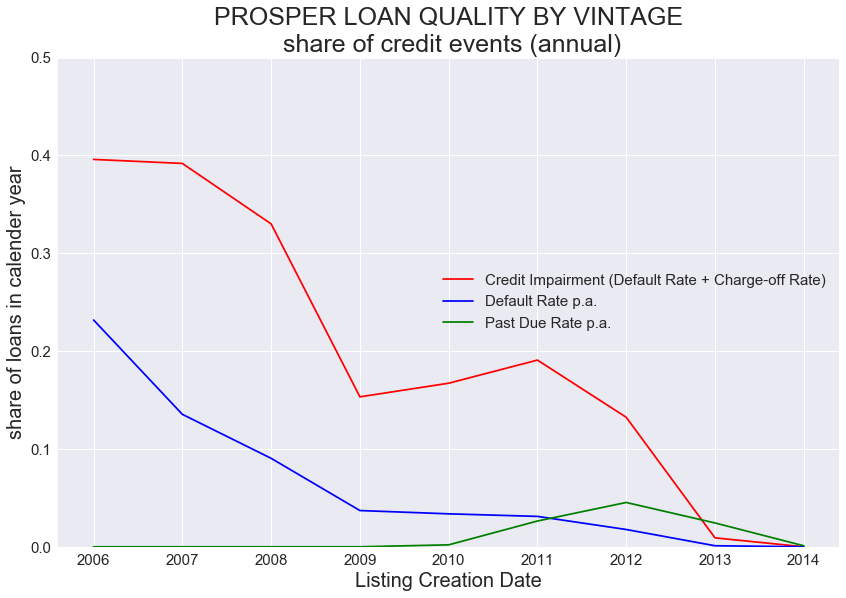

```python
plt.figure(figsize=(14,9))
plt.title('PROSPER LOAN QUALITY BY VINTAGE\n share of credit events (annual)', fontsize=25)
plt.plot(CreditQuality_df['credit_impairment'],label = 'Credit Impairment (Default Rate + Charge-off Rate)', color='r')
plt.plot(CreditQuality_df['default_rate'],label = 'Default Rate p.a.', color='b')
plt.plot(CreditQuality_df['past_due_rate'],label = 'Past Due Rate p.a.', color='g')
plt.legend(loc= 'center right', fontsize=15)
plt.ylabel('share of loans in calender year', fontsize=20)
plt.xlabel('Listing Creation Date', fontsize=20)
plt.ylim(0,.5)
plt.xticks( rotation=0, fontsize=15)
plt.yticks( rotation=0, fontsize=15)
plt.show()
```

The chart shows that the Credit Impairment rate declined from 40% in 2006 to approx. 15% in 2009. Impairments climed up again until reaching approx. 19% in 2011. Thereafter, the Credit Impairments rate declined to 13% in 2012 and 1% in 2013. However, we have to keep in mind that a large number of loans were originated since 2012. Typically borrowers do not default in the 1st year and Credit Impairments will likely rise for recent vintages.

What is the distribution of Credit Impairments over the rating classes?

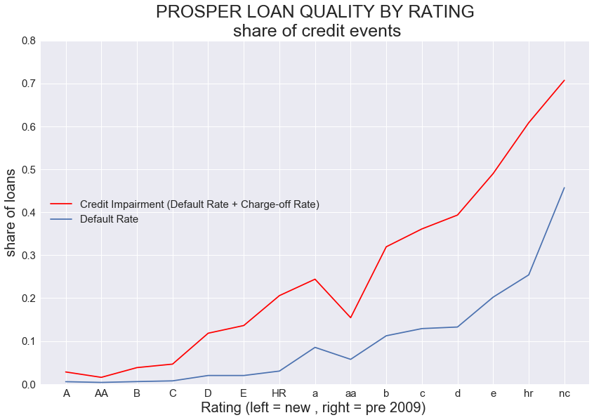

```python
D = (Defaulted_filter['Rating'].value_counts() / loan_master['Rating'].value_counts())
I = ((Defaulted_filter['Rating'].value_counts() + Chargedoff_filter['Rating'].value_counts()  ) / loan_master['Rating'].value_counts())

plt.figure(figsize=(14,9))
plt.title('PROSPER LOAN QUALITY BY RATING\n share of credit events', fontsize=25)
plt.plot(I,label = 'Credit Impairment (Default Rate + Charge-off Rate)', color='r')
plt.plot(D,label = 'Default Rate')


plt.legend(loc= 'center left', fontsize=15)
plt.ylabel('share of loans', fontsize=20)
plt.xlabel('Rating (left = new , right = pre 2009) ', fontsize=20)
plt.ylim(0,.8)
plt.xticks( rotation=0, fontsize=15)
plt.yticks( rotation=0, fontsize=15)
plt.show()
```

The chart shows that credit events are more frequent for lower rated loans. Furthermore, loans rated before 2009 (i.e. CreditGrades 'aa' - 'nc') have significantly higher credit impairment rates than loans originated after 2009 (i.e. ProsperRatings 'AA' - 'HR').

Let us now turn to the pricing of credit risk.

### Borrower APR

> The Borrower's Annual Percentage Rate (APR) for the loan.

### CreditScoreRangeLower (Definition)

> The lower value representing the range of the borrower's credit score as provided by a consumer credit rating agency.

### CreditScoreRangeUpper (Definition)

> The upper value representing the range of the borrower's credit score as provided by a consumer credit rating agency.

Following Prosper's SEC registration in 2009, new prospective borrowers are required to have an FICO 8 credit score of at least 640, while returning borrowers only need a score of 600 to request a loan (Source: Wikipedia).

The Base FICO® scores range from 300 to 850. FICO breaks down its base credit score ranges based on the FICO® Score 8 credit-scoring model.

```
FICO® Score 8
Poor       300 to 559
Fair       580 to 669
Good       670 to 739
Very Good   740 to 799
Excellent   800 to 850
```

Source: https://www.creditkarma.com/advice/i/good-fico-score-range/

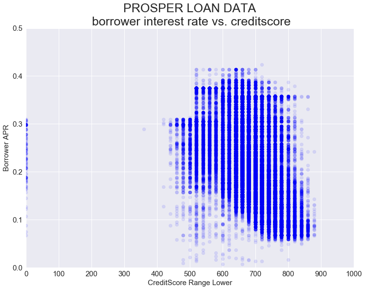

```python
plt.figure(figsize = [12, 9])
plt.scatter(data = loan_master, x = 'CreditScoreRangeLower', y = 'BorrowerAPR', color='b', alpha = 1/10)
plt.title('PROSPER LOAN DATA\n borrower interest rate vs. creditscore', fontsize=25)
plt.xticks([0,100,200,300,400,500,600,700,800,900,1000], rotation=0, fontsize=15)
plt.yticks([0,0.1,0.2,0.3,0.4,0.5], rotation=0, fontsize=15)
plt.xlim([0, 1000])
plt.ylim([0, 0.5])
plt.xlabel('CreditScore Range Lower', rotation=0, fontsize=15)
plt.ylabel('Borrower APR', rotation=90, fontsize=15)
plt.show();
```

The scatter plot depicts small blue circles for each loan in the dataframe. The vertical axis measures the variable **`BorrowerAPR`** and the horizontal axis is grouped by the variable **`CreditScoreRangeLower`**. The dots are translucent and higher frequencies of loans (i.e. dots) with the same BorrowerAPR show darker. We notice that the ranges of BorrowerAPR by CreditScore are very high (+30%points). Apparently, there is no strong relationship between the CreditScore and BorrowerAPR. However, we can see that CreditScores below 700 are typically associated with higher minimum BorrowerAPRs.

Let us look at the correlation of BorrowerAPR with other numerical variables.

```python
numeric_vars = ['BorrowerAPR', 'EstimatedLoss', 'EstimatedReturn', 'TotalInquiries', 'LP_NetPrincipalLoss' ,\
                'LP_GrossPrincipalLoss' , 'TOT', 'P&L', 'DebtToIncomeRatio', \
                'EmploymentStatusDuration','StatedMonthlyIncome', 'CurrentCreditLines', \
                'Investors', 'CreditScoreRangeLower']
```

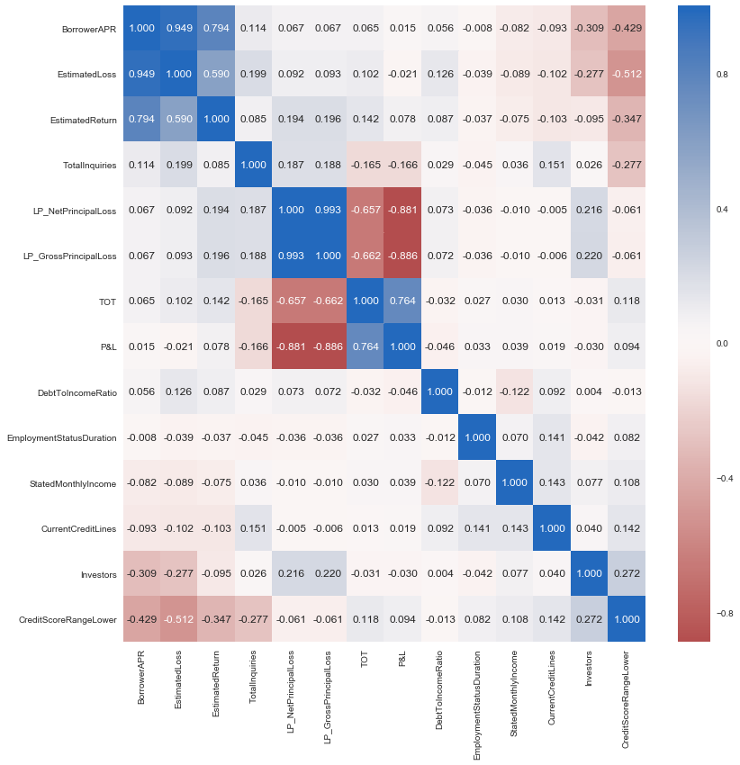

```python
# correlation plot
plt.figure(figsize = [13, 13])
sb.heatmap(loan_master[numeric_vars].corr(), annot = True, fmt = '.3f',
           cmap = 'vlag_r', center = 0)
plt.show()
```

Let us turn to categorical variables now. We use a random sample of loans to produce meaningful boxplot diagrams.

```python
categoric_vars = ['Rating_numeric', 'IncomeRange']
categoric_vars2 = ['EmploymentStatus','IsBorrowerHomeowner', 'IncomeVerifiable']
```

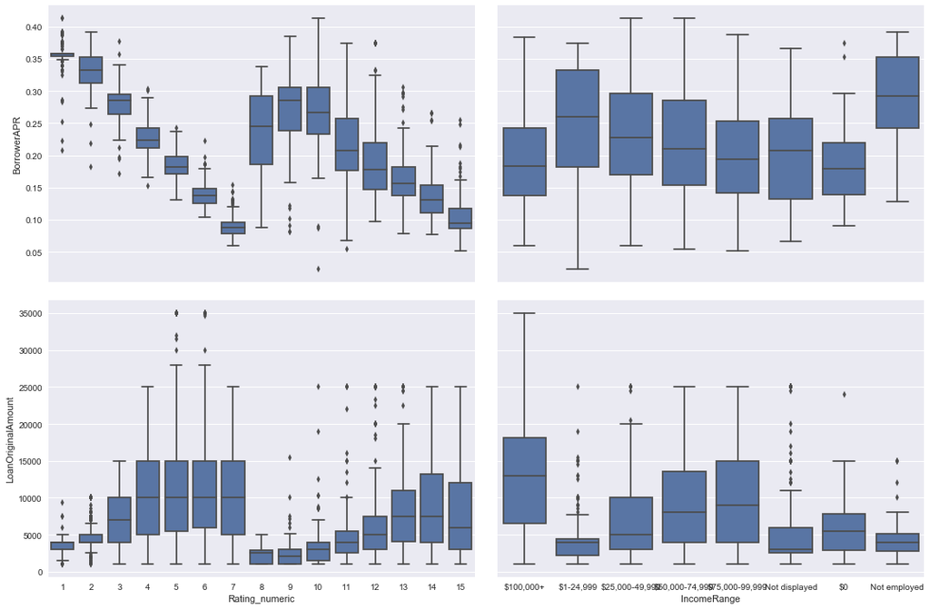

```python
# plot matrix of numeric features against categorical features.
# can use a larger sample since there are fewer plots and they're simpler in nature.

samples = np.random.choice(loan_master.shape[0], 5000, replace = False)
loan_master_samp = loan_master.loc[samples,:]

def boxgrid(x, y, **kwargs):
    """ Quick hack for creating box plots with seaborn's PairGrid. """
    default_color = sb.color_palette()[0]
    sb.boxplot(x, y, color = default_color)

plt.figure(figsize = [20, 20])
g = sb.PairGrid(data = loan_master_samp, y_vars = ['BorrowerAPR', 'LoanOriginalAmount'], x_vars = categoric_vars,
                size = 5, aspect = 1.5)
g.map(boxgrid)


plt.show();
```

Categorical variable Ratings_numerical

'N/A' : '0' , 'HR': '1' , 'E': '2' , 'D': '3' , 'C': '4' , 'B': '5' , 'A': '6' , 'AA': '7' ( used now )

**Upper left**: Apparently, there is a negative relationships between the categorical variables `Rating` and the numeric variable `Borrower APR`. It is clearly visible that loans with higher credit quality tend to have lower BorrowerAPRs. While the Dutch-auction process used for interest rate setting before 2009 still produced some overlap, thereafter the interquartile ranges of different rating classes do not overlap any more.

**Upper right**: Borrowers in the USD 0-24,999 income bracket and those who are not employed pay higher average interest rates than borrowers from other income brackets. Borrowers with income above USD 100,000 pay the lowest average rates.

**Lower left**: Loans with higher ratings (i.e. better credit quality) have larger average Loan Original Amounts. Borrowers with low ratings 'HR': '1' , 'E': '2' , 'D': '3' and 'nc': '8' , 'hr': '9','e': '10' are conatraint to lower loan volumes. However, since the introduction of the new rating methodology in 2009 average loan volumen have increased for all rating classes.

Next, let us find out whether investors are right to favour borrowers with higher income. Do borrowers with higher income tend to have fewer credit events?

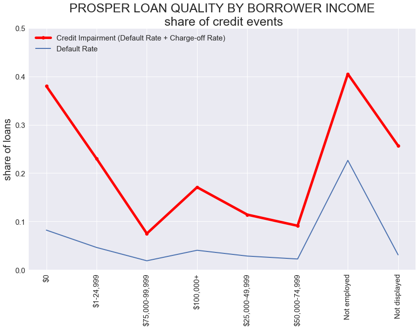

```python
X = (Defaulted_filter['IncomeRange'].value_counts() / loan_master['IncomeRange'].value_counts() )
Y = ((Chargedoff_filter['IncomeRange'].value_counts() + Defaulted_filter['IncomeRange'].value_counts() )\
     / loan_master['IncomeRange'].value_counts() )

plt.figure(figsize=(14,9))
plt.title('PROSPER LOAN QUALITY BY BORROWER INCOME\n share of credit events', fontsize=25)
plt.plot(Y, 'ro-', label = 'Credit Impairment (Default Rate + Charge-off Rate)', linewidth=5)
plt.plot(X,label = 'Default Rate', linewidth=2)
plt.xticks(["$0",'$1-24,999','$25,000-49,999','$50,000-74,999','$75,000-99,999',\
            '$100,000+','Not employed','Not displayed'], rotation=90, fontsize=15)

plt.legend(loc= 'upper left', fontsize=15)
plt.ylabel('share of loans', fontsize=20)
plt.ylim(0,.5)
plt.yticks( rotation=0, fontsize=15)
plt.show();
```

Investors are right to penalize borrowers with low income, but they should be more careful providing loans to borrowers with very high income and to borrowers who do not display income. While the interest rate is determined by the Prosper rating since 2009, investors should limit the volume they provide to those borrowers. Borrowers with high income frequently request large loan amounts, but investors should not perceive them as low risk investments. Furthermore, investors should be very careful providing any credit to borrowers who do not display their income.

Next, let us investigate the categorical variable **`EmploymentStatus`** and the two boolean variables **`IsBorrowerHomeowner`** and **`IncomeVerifiable`**. What is the ratationsship with the numerical variables **`BorrowerAPR`** and **`LoanOriginalAmount`**?

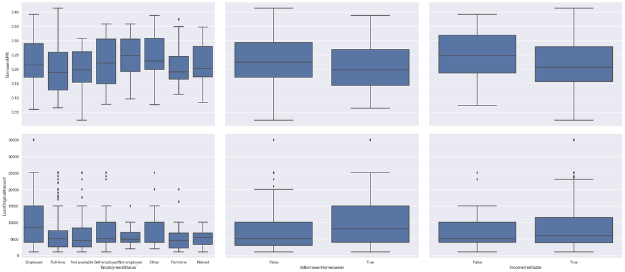

```python
# plot matrix of numeric features against categorical features.
# can use a larger sample since there are fewer plots and they're simpler in nature.

samples = np.random.choice(loan_master.shape[0], 2000, replace = False)
loan_master_samp = loan_master.loc[samples,:]

def boxgrid(x, y, **kwargs):
    """ Quick hack for creating box plots with seaborn's PairGrid. """
    default_color = sb.color_palette()[0]
    sb.boxplot(x, y, color = default_color)

plt.figure(figsize = [20, 20])
g = sb.PairGrid(data = loan_master_samp, y_vars = ['BorrowerAPR', 'LoanOriginalAmount'], x_vars = categoric_vars2,
                size = 5, aspect = 1.5)
g.map(boxgrid)


plt.show();
```

**Upper left**: Borrowers with **`Employmentstatus`** 'Not-employed' pay higher average **`BorrowerAPR`** on loans. Surprisingly, borrowers with EmployementStatus 'Not available' and 'Full-time' both pay the lowest average rates.

**Lower Left**: Borrowers with **`Employmentstatus`** 'Full-time' , 'Retired' and 'Part-time' get the smallest loan volumes, while 'Employed' and Self-Employed' get the largest.

**Upper middle**: Borrower who are homeowners ( **`IsBorrowerHomeowner`** = True ) pay slidely lower rates.

**Lower middle**: Borrower who are homeowners ( **`IsBorrowerHomeowner`** = True ) get significantly larger loans.

**Upper right**: Borrower who can provide proof of income ( **`IncomeVerifiable`** = True ) pay slightly lower rates.

**Lower right**: Borrower who can provide proof of income ( **`IncomeVerifiable`** = True ) get slightly larger loans.

Is it justified to give larger loans at lower rates to borrowers who own houses? What is the percentage of homeowners for all loans?

```python
print(round(Defaulted_filter['IsBorrowerHomeowner'].mean(),3),' share of defaults with borrowers who are homeowners.')
print(round(Chargedoff_filter['IsBorrowerHomeowner'].mean(),3),' share of chargedoffs with borrowers who are homeowners.')
print()
print(round(loan_master['IsBorrowerHomeowner'].mean(),3),' share of all loans with borrowers who are homeowners.')
```

```
0.453  share of defaults with borrowers who are homeowners.
0.445  share of chargedoffs with borrowers who are homeowners.

0.505  share of all loans with borrowers who are homeowners.
```

Yes, about 50% of all borrowers are homeowners, but only 45% of defaults and 44% of chargedoffs involve homeowners.

Let us calculate this ratios for the variable **`IncomeVerifiable`**.

```python
print(round(Defaulted_filter['IncomeVerifiable'].mean(),3),' share of defaults with verifiable income.')
print(round(Chargedoff_filter['IncomeVerifiable'].mean(),3),' share of chargedoffs with verifiable income.')
print()
print(round(loan_master['IncomeVerifiable'].mean(),3),' share of all loans with verifiable income.')
```

```
0.949  share of defaults with verifiable income.
0.895  share of chargedoffs with verifiable income.

0.924  share of all loans with verifiable income.
```

The result is not conclusive. While 92% of all loans have verifiable income, 95% of defaults but only 90% of chargedoffs have verifiable income.

Now let us look at the rate of credit events by employment status.

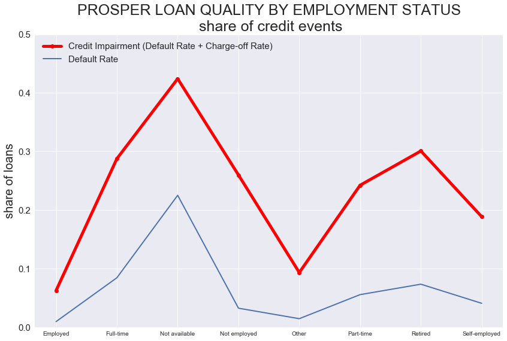

```python
X = (Defaulted_filter['EmploymentStatus'].value_counts() / loan_master['EmploymentStatus'].value_counts() )
Y = ((Chargedoff_filter['EmploymentStatus'].value_counts() + Defaulted_filter['EmploymentStatus'].value_counts()) \
      / loan_master['EmploymentStatus'].value_counts() )


plt.figure(figsize=(14,9))
plt.title('PROSPER LOAN QUALITY BY EMPLOYMENT STATUS\n share of credit events', fontsize=25)
plt.plot(Y, 'ro-', label = 'Credit Impairment (Default Rate + Charge-off Rate)', linewidth=5)
plt.plot(X,label = 'Default Rate', linewidth=2)
plt.legend(loc= 'upper left', fontsize=15)
plt.ylabel('share of loans', fontsize=20)
plt.ylim(0,.5)
plt.yticks( rotation=0, fontsize=15)
plt.show();
```

Loans with **`EmploymentStaus`** 'Employed' have the lowerest credit impairment rate below 10%, followed by 'Other' at 10% and 'Self-employed' below 20%. In contrast, 'Not available' has the highest delinquency rate above 40%.

### Talk about some of the relationships you observed in this part of the investigation. How did the feature(s) of interest vary with other features in the dataset?

> We have defined the variables Profit and Loss (**`P&L`**) and Total Return(**`TOT`**) to evaluate the impact of defaults and charge offs on investors' return. For loans the P&L and TOT is predefined by the loan amount, the interest rate and the term to maturity. The high interest rates on Prosper loans suggest attractive investment returns. However, the realized loss on charged off or defaulted loans was -50% of principal and more. Therefore, reducing the likelihood of credit impairments is the best way to improve the portfolio return.

> We have looked at the rate of credit impairments (i.e. defaults and charge offs) by rating and by calendar year. Credit impairment rates were highest for loans issued before 2009 (i.e. Vintage 2006, 2007 and 2008). While the default rates have kept low thereafter, the rate of charge offs has picked-up again. Both defaults and charge offs have a similar negative impact on investors total return, and we should treat them the same. Credit Impairment rate declined from 40% in 2006 to approx. 15% in 2009. Impairments climbed up again until reaching approx. 19% in 2011. Thereafter, the Credit Impairments rate declined to 13% in 2012 and 1% in 2013. However, we must keep in mind that many loans were originated since 2012. Typically, borrowers do not default in the 1st year and Credit Impairments will likely rise for recent vintages. Therefore, a **credit impairment rate of 15-20% per vintage year should be expected in normal times, but an economic downturn can lead to a sharp increase**.

### Did you observe any interesting relationships between the other features (not the main feature(s) of interest)?

> We have look at the relationsship between the two categorical variables **`EmploymentStatus`** and **`IncomeRange`** and credit impairment rates. The categories can serve as indicators for credit risk. A very low or very high income is a good predictor of increased credit impairment risk. An Employment Status of 'Employed' signals the lowest risk of delinquencies while an status of 'Not avaiable' is most risky.

## Multivariate Exploration

> Let us start with the definition of some useful filters for vintage years.

```python
# We use values of the variable LoanOriginationQuarter (String-format) for a query on the dataframe loan_master.

Vintage2006_filter            = loan_master.query("LoanOriginationQuarter == 'Q1 2006' \
                        or LoanOriginationQuarter == 'Q2 2006' or LoanStatus == 'Q3 2006' or LoanStatus == 'Q4 2006'")

Vintage2007_filter            = loan_master.query("LoanOriginationQuarter == 'Q1 2007' \
                        or LoanOriginationQuarter == 'Q2 2007' or LoanStatus == 'Q3 2007' or LoanStatus == 'Q4 2007'")

Vintage2008_filter            = loan_master.query("LoanOriginationQuarter == 'Q1 2008' \
                        or LoanOriginationQuarter == 'Q2 2008' or LoanStatus == 'Q3 2008' or LoanStatus == 'Q4 2008'")

Vintage2009_filter            = loan_master.query("LoanOriginationQuarter == 'Q1 2009' \
                        or LoanOriginationQuarter == 'Q2 2009' or LoanStatus == 'Q3 2009' or LoanStatus == 'Q4 2009'")

Vintage2010_filter            = loan_master.query("LoanOriginationQuarter == 'Q1 2010' \
                        or LoanOriginationQuarter == 'Q2 2010' or LoanStatus == 'Q3 2010' or LoanStatus == 'Q4 2010'")

Vintage2011_filter            = loan_master.query("LoanOriginationQuarter == 'Q1 2011' \
                        or LoanOriginationQuarter == 'Q2 2011' or LoanStatus == 'Q3 2011' or LoanStatus == 'Q4 2011'")

Vintage2012_filter            = loan_master.query("LoanOriginationQuarter == 'Q1 2012' \
                        or LoanOriginationQuarter == 'Q2 2012' or LoanStatus == 'Q3 2012' or LoanStatus == 'Q4 2012'")

Vintage2013_filter            = loan_master.query("LoanOriginationQuarter == 'Q1 2013' \
                        or LoanOriginationQuarter == 'Q2 2013' or LoanStatus == 'Q3 2013' or LoanStatus == 'Q4 2013'")

Vintage2014_filter            = loan_master.query("LoanOriginationQuarter == 'Q1 2014' \
                        or LoanOriginationQuarter == 'Q2 2014' or LoanStatus == 'Q3 2014' or LoanStatus == 'Q4 2014'")
```

We define a function to generate headmaps in 2 dimensions (2D).

```python
def hist2dgrid(x, y, **kwargs):
    """ Quick hack for creating heat maps with seaborn's PairGrid. """
    palette = kwargs.pop('color')
    bins_x = np.arange(0, 15, 1)
    bins_y = np.arange(0.0,0.5, 0.05)
    plt.hist2d(x, y, bins = [bins_x, bins_y], cmap = palette, cmin = 0.5)
```

## Risk-Return Tradeoff

We generate 12 headmaps for all the categories of the variable **`LoanStatus`**. The categorical variable **`Rating`** is the horizontal axis and the numerical variable **`BorrowerAPR`** is the vertical axis.

Each headmap depicts the frequency of loans in Rating - BorrowerAPR space. Darker pixels are more frequent then lighter once.

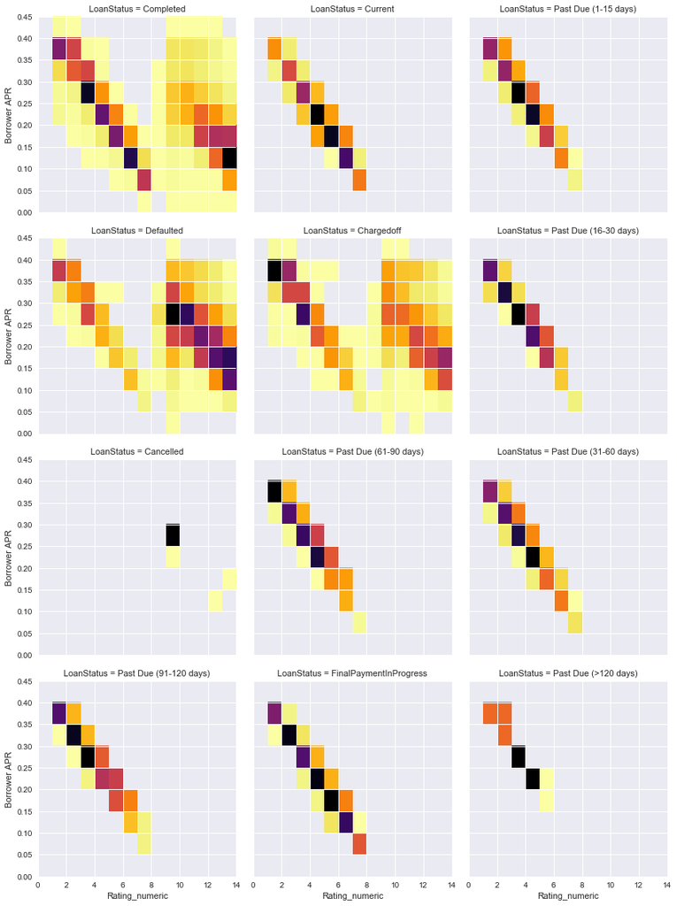

```python
# create faceted heat maps on levels of the Loan Status variable
g = sb.FacetGrid(data = loan_master, col = 'LoanStatus', col_wrap = 3, size = 4, xlim = [0,10])
g.map(hist2dgrid, 'Rating_numeric', 'BorrowerAPR', color = 'inferno_r')
g.set_xlabels('Rating_numeric')
g.set_ylabels('Borrower APR')
#CreditScoreRangeLower
plt.show()
```

Since 2009 interest rates for loans are pre-determined by Prosper and investors can only choose how much to invest or not to invest in a loan at a given rate. The rate is determined according to the expected rate of return associated with the rating of a loan. Accordingly, we see a **linear ex-ante risk/return pattern for the new Ratings**. Furthermore, with chargedoffs we see a higher frequency of lower rated loans in delinquency (i.e. ex-post risk/return relationship).

Previously, a Dutch Auction system was in place to find the interest rate in an eBay-style bidding process. We must keep in mind that most investors in Prosper loans are not professionals. Furthermore, the Rating methodology pre 2009 was less strict. Consequently, **the ex-ante Risk/Return pattern for the old ratings is rather blurred**. Furthermore, we see a high frequency of defaults and charge offs for highly rated loans issued before 2009.

### </font> Finding

> Both the rating methodology and the rate setting mechanism used by Prosper before 2009 were fundamentally flawed, leading to an overestimation of credit quality and a mispricing of risk.

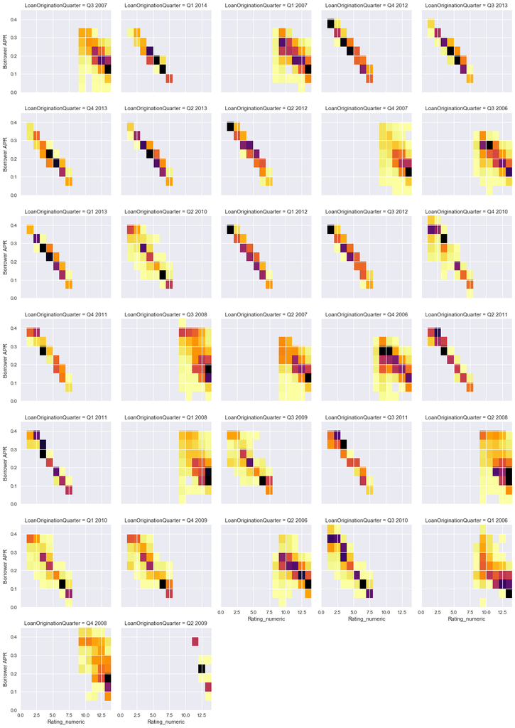

```python
# create faceted heat maps on levels of the Loan Origination Quarter variable
g = sb.FacetGrid(data = loan_master, col = 'LoanOriginationQuarter', col_wrap = 5, size = 3, xlim = [0,10])
g.map(hist2dgrid, 'Rating_numeric', 'BorrowerAPR', color = 'inferno_r')
g.set_xlabels('Rating_numeric')
g.set_ylabels('Borrower APR')

plt.show()
```

Next, let us create **violine plots** to visualize the frequency of the **`LoanStatus`** categories 'default' and 'chargedoff' by **`Rating`** and **`BorrowerAPR`**. A violin plot plays a similar role as a box and whisker plot. It shows the distribution of quantitative data across several levels of one (or more) categorical variables such that those distributions can be compared. Unlike a box plot, in which all of the plot components correspond to actual datapoints, the violin plot features a kernel density estimation of the underlying distribution. This can be an effective and attractive way to show multiple distributions of data at once, but keep in mind that the estimation procedure is influenced by the sample size, and violins for relatively small samples might look misleadingly smooth. (Source: Seaborn documentation)

```python
# assist function for plotting
def rate_by_rating(var, text, color):
    ProsperRating = 'HR','E','D','C','B','A','AA'
    CreditGrade   = 'hc','hr','e','d','c','b','a','aa'
    fig, ax = plt.subplots(ncols = 2, figsize = [12,7])
    sb.violinplot(data = var, y = 'BorrowerAPR', x = 'ProsperRating (Alpha)', ax = ax[0],
                  color = color, order=ProsperRating)

    ax[0].set_xlabel("Prosper Rating")
    sb.violinplot(data = var, y = 'BorrowerAPR', x = 'CreditGrade', ax = ax[1],
               color = color, order=CreditGrade)
    ax[1].set_xlabel("CreditGrade")
    fig.suptitle('Interest Rate by Rating for {}'.format(text.capitalize()))
    plt.ylim(0,.45)
    plt.show()
```

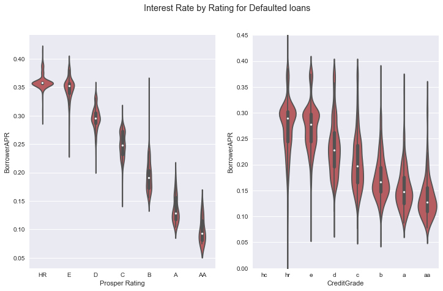

```
hr    891
c     729
d     684
e     665
b     493
a     283
D     282
HR    209
aa    201
E     193
C     134
B      88
A      79
nc     64
AA     20
Name: Rating, dtype: int64
```

```python
rate_by_rating(Defaulted_filter, 'Defaulted Loans', sb.color_palette()[2])
Defaulted_filter['Rating'].value_counts()
```

The violin plot for LoanStatus = 'Defaulted' show that all scales of the CreditGrade spectrum experienced a high number of defaults and the distribution of interest rates for CreditGrade scales overlap. In contrast, the number of defaults for ProsperRating concentrate on the low rating classes ‘HR’, ‘E’ and ‘D’. For ProsperRatings the distributions of interest rates do hardly overlap.

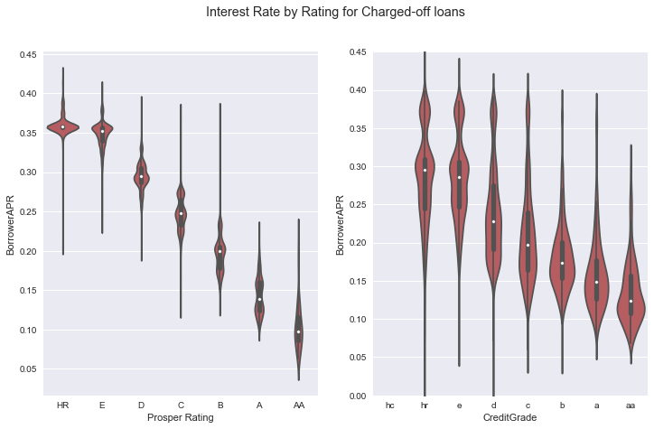

```
hr    891
c     729
d     684
e     665
b     493
a     283
D     282
HR    209
aa    201
E     193
C     134
B      88
A      79
nc     64
AA     20
Name: Rating, dtype: int64
```

```python
rate_by_rating(Chargedoff_filter, 'Charged-off Loans', sb.color_palette()[2])
Defaulted_filter['Rating'].value_counts()
```

The violin plot for **`LoanStatus`** = 'Chargedoff' show that all scales of the CreditGrade spectrum experience an almost equal number of charged-offs and the distribution of interest rates for CreditGrade scales overlap. In comparison, the number of charged-offs for ProsperRating concentrate on the low rating classes ‘HR’, ‘E’ and ‘D’ and interest rate distributions do not overlap as much.

Since December 2010, borrower interest rates are determined by Prosper based on their calculation of estimated return. There is no public information as to how Prosper calculates borrower interest rate, but we do know they consider credit data such as number of inquiries, available credit, credit card utilization, and recent delinquencies. However, data for the variables **`Estimated Return`** , **`EstimatedEffectiveYield`** and **`EstimatedLoss`** is available for every loan originated since July 2009.

### Estimated Return (Definition)

> The estimated return assigned to the listing at the time it was created. Estimated return is the **difference between the Estimated Effective Yield and the Estimated Loss Rate**. Applicable for loans originated after July 2009.

### Estimated Effective Yield (Definition)

> Effective yield is equal to the borrower interest rate (i) minus the servicing fee rate, (ii) minus estimated uncollected interest on charge-offs, (iii) plus estimated collected late fees. Applicable for loans originated after July 2009.

### Estimated Loss (Definition)

> Estimated loss is the estimated principal loss on charge-offs. Applicable for loans originated after July 2009.

Let us visualise the distribution of **`BorrowerAPR`** and **`EstimatedReturn`** for the loans in recent vintages.

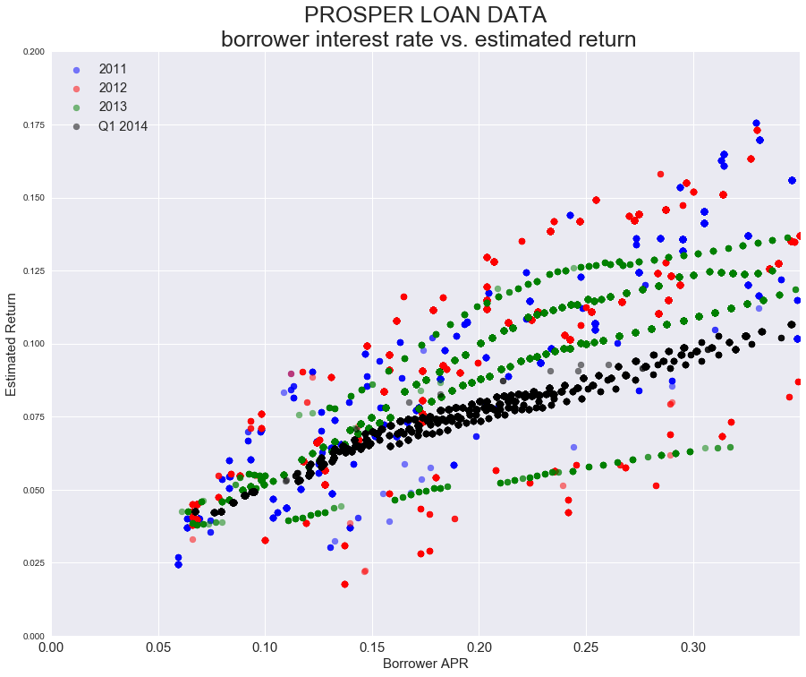

```python
text = ['2011', '2012' , '2013', 'Q1 2014']

plt.figure(figsize = [15, 12])
plt.scatter(data = Vintage2011_filter, y = 'EstimatedReturn', x = 'BorrowerAPR', color='b', alpha = 1/2)
plt.scatter(data = Vintage2012_filter, y = 'EstimatedReturn', x = 'BorrowerAPR', color='r', alpha = 1/2)
plt.scatter(data = Vintage2013_filter, y = 'EstimatedReturn', x = 'BorrowerAPR', color='g', alpha = 1/2)
plt.scatter(data = Vintage2014_filter, y = 'EstimatedReturn', x = 'BorrowerAPR', color='k', alpha = 1/2)
plt.title('PROSPER LOAN DATA\n borrower interest rate vs. estimated return', fontsize=25)
#plt.xticks(['AA','A','B','C','D','E','HR'], rotation=0, fontsize=15)
plt.xticks([0, 0.05, 0.1, 0.15, 0.2, 0.25, 0.3], rotation=0, fontsize=15)
#plt.yticks([0,0.1,0.2,0.3,0.4,0.5], rotation=0, fontsize=15)
plt.xlim([0, 0.35])
plt.ylim([0, 0.2])
plt.xlabel('Borrower APR', rotation=0, fontsize=15)
plt.ylabel('Estimated Return', rotation=90, fontsize=15)
plt.legend(text, fontsize='large')
plt.show();
```

According to the company, Loan interest rates in their social lending marketplace are set by Prosper and based on factors including:

```
Prosper Rating, which is an indicator of expected loss rates
Loan term
Economic environment
Competitive environment
```

Source: www.prosper.com/loans/rates-and-fees

Now, let us visualise the distribution of **`BorrowerAPR`** and **`EstimatedLoss`** for the loans in recent vintages.

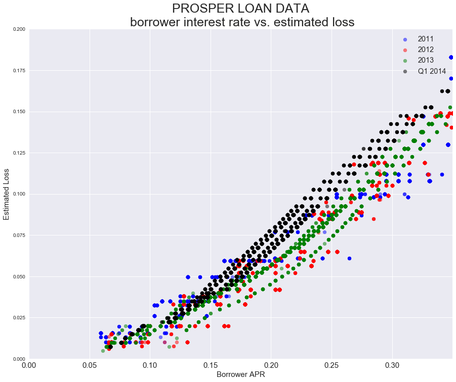

```python
text = ['2011', '2012' , '2013', 'Q1 2014']

plt.figure(figsize = [15, 12])
plt.scatter(data = Vintage2011_filter, y = 'EstimatedLoss', x = 'BorrowerAPR', color='b', alpha = 1/2)
plt.scatter(data = Vintage2012_filter, y = 'EstimatedLoss', x = 'BorrowerAPR', color='r', alpha = 1/2)
plt.scatter(data = Vintage2013_filter, y = 'EstimatedLoss', x = 'BorrowerAPR', color='g', alpha = 1/2)
plt.scatter(data = Vintage2014_filter, y = 'EstimatedLoss', x = 'BorrowerAPR', color='k', alpha = 1/2)
plt.title('PROSPER LOAN DATA\n borrower interest rate vs. estimated loss', fontsize=25)
#plt.xticks(['AA','A','B','C','D','E','HR'], rotation=0, fontsize=15)
plt.xticks([0, 0.05, 0.1, 0.15, 0.2, 0.25, 0.3], rotation=0, fontsize=15)
#plt.yticks([0,0.1,0.2,0.3,0.4,0.5], rotation=0, fontsize=15)
plt.xlim([0, 0.35])
plt.ylim([0, 0.2])
plt.xlabel('Borrower APR', rotation=0, fontsize=15)
plt.ylabel('Estimated Loss', rotation=90, fontsize=15)
plt.legend(text, fontsize='large')
plt.show();
```

## Estimated Loss

For loans issued in Q1 2014, there is an approx. linear relationship between **BorrowerAPR** and **Estimated Loss** visible. For example, BorrowerAPRs of 10%, 20% and 30% are associated with an estimated loss of approx. 2.5%, 7.5% and 14%, respectively. For 2013, there are 2 trade-off curves with different slopes visible. For 2011 and 2012 there is no clear trade-off curves visible between BorrowerAPR and Estimated Loss.

Next, let us look at the realized total return (TOT) by rating.

```python
# assist function for plotting
def tot_by_rating(var, text, color):
    ProsperRating = 'HR','E','D','C','B','A','AA'
    CreditGrade   = 'hc','hr','e','d','c','b','a','aa'
    fig, ax = plt.subplots(ncols = 2, figsize = [12,7])
    sb.barplot(data = var, y = 'TOT', x = 'ProsperRating (Alpha)', ax = ax[0],
                  color = color, order=ProsperRating)
    ax[0].set_xlabel("Prosper Rating")
    sb.barplot(data = var, y = 'TOT', x = 'CreditGrade', ax = ax[1],
               color = color, order=CreditGrade)
    ax[1].set_xlabel("CreditGrade")
    fig.suptitle('Total Return by Rating for {}'.format(text.capitalize()))
    plt.show()
```

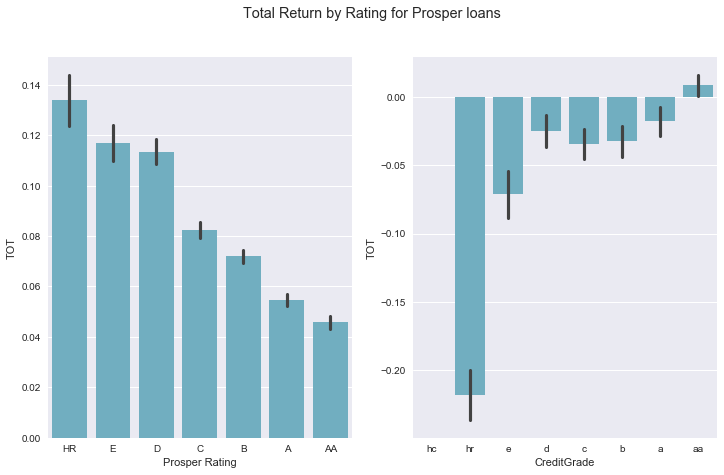

```
54920   Number of closed loans
112910  Number of total loans
49.0  % of all loans are closed already.
939.5 million USD nominal amount.
8321 USD average loan size.
```

```python
tot_by_rating(loan_master, 'Prosper Loans', sb.color_palette()[5])
print(loan_master.ClosedDate.count(), '  Number of closed loans')
print(loan_master.shape[0],' Number of total loans')
print((round(loan_master.ClosedDate.count() / loan_master.shape[0],2)*100),' % of all loans are closed already.')
print(round(loan_master.LoanOriginalAmount.sum()/1000000,1),'million USD nominal amount.')
print(round(loan_master.LoanOriginalAmount.mean(),),'USD average loan size.')
```

The two barplot charts show the average total return **`TOT`** by **`Rating`** for the new Prosper Ratings (left) and the old CreditGrade (right). The total return is negative for all scales of the CreditGrade spectrum except top-rated 'aa'. In general, for loans originated before 2009, a lower credit quality is associated with a lower total return. The worst investment performance was generated in the lowest CreditGrades 'e' and 'hr'. The moderate magnitude of the negative total returns indicate that most loans paid interest and amortized principal for some time before they went into delinquency, providing a cushion. The volatility is high for all CreditGrades.

In sharp contrast, new loans originated since 2009 show ascending positive total returns and increasing volatility for lower rating classes. However, most of the loans with a Prosper Rating are still outstanding with a large share of recently issued loans. Therefore, we should look at particular vintages.

In this part of the Multivariate Exploration we can use the **`CreditQuality_df`** table again that we have created in Bivariate Exploration.

```python
CreditQuality_df
```

|  | Defaulted | Chargedoff | Completed | Current | Cancelled | FinalPaymentInProgress | Past_Due | Total | default_rate | chargedoff_rate | credit_impairment | past_due_rate |
| --- | --- | --- | --- | --- | --- | --- | --- | --- | --- | --- | --- | --- |
| 2006 | 1435 | 1016 | 3736 | 0 | 4 | 0 | 0 | 6191 | 0.231788 | 0.164109 | 0.395897 | 0.000000 |
| 2007 | 1559 | 2953 | 7004 | 0 | 0 | 0 | 0 | 11516 | 0.135377 | 0.256426 | 0.391803 | 0.000000 |
| 2008 | 1009 | 2674 | 7476 | 0 | 1 | 0 | 0 | 11160 | 0.090412 | 0.239606 | 0.330018 | 0.000000 |
| 2009 | 81 | 254 | 1851 | 0 | 0 | 0 | 0 | 2186 | 0.037054 | 0.116194 | 0.153248 | 0.000000 |
| 2010 | 186 | 737 | 4557 | 30 | 0 | 0 | 11 | 5521 | 0.033690 | 0.133490 | 0.167180 | 0.001992 |
| 2011 | 355 | 1825 | 5512 | 3393 | 0 | 39 | 301 | 11425 | 0.031072 | 0.159737 | 0.190810 | 0.026346 |
| 2012 | 345 | 2238 | 5439 | 10550 | 0 | 55 | 884 | 19511 | 0.017682 | 0.114705 | 0.132387 | 0.045308 |
| 2013 | 37 | 280 | 2214 | 31177 | 0 | 92 | 844 | 34644 | 0.001068 | 0.008082 | 0.009150 | 0.024362 |
| 2014 | 0 | 0 | 61 | 10396 | 0 | 17 | 11 | 10485 | 0.000000 | 0.000000 | 0.000000 | 0.001049 |

Let us define a function that produces two charts for each vintage: Total return (left) and Estimated Return (right)

```python
# assist function for plotting
def tot_by_rating_vintage(var, text, color):
    ProsperRating = 'HR','E','D','C','B','A','AA'
    CreditGrade   = 'hc','hr','e','d','c','b','a','aa'
    fig, ax = plt.subplots(ncols = 2, figsize = [12,7])
    sb.barplot(data = var, y = 'TOT', x = 'ProsperRating (Alpha)', ax = ax[0],
                  color = color, order=ProsperRating)
    ax[0].set_xlabel("Prosper Rating")
    sb.boxplot(data = var, y = 'EstimatedReturn', x = 'ProsperRating (Alpha)', ax = ax[1],
               color = color, order=ProsperRating)
    ax[1].set_xlabel("Prosper Rating")
    fig.suptitle('Total Return (left) and Estimated Return (right) for {}'.format(text.capitalize()))
    plt.show()
```

Let us start with the 2010 vintage, because it is the first year after the financial crisis. The more sophisticated ProsperRating was already in place by then, but the old Dutch-Auction rate setting mechanism or some variation thereof was still used. The credit impairment rate in 2010 was 16.7% and less than 1% of loan are still outstanding.

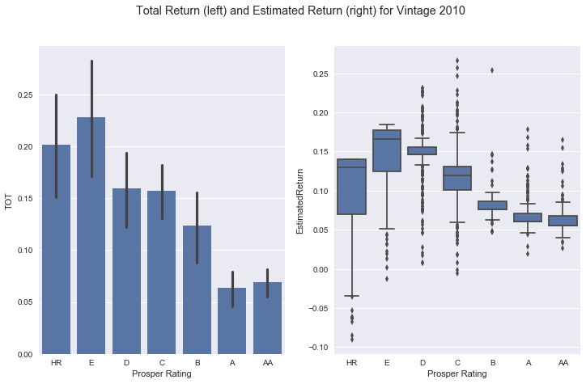

```
2743 number of closed loans
2744 number of total loans
100.0 % of loans are closed already.
36 months term to maturity(average)
12.2 million USD nominal amount.
4429 USD average loan size.
```

```python
tot_by_rating_vintage(Vintage2010_filter, 'Vintage 2010', sb.color_palette()[0])
print(Vintage2010_filter.ClosedDate.count(), 'number of closed loans')
print(Vintage2010_filter.shape[0],'number of total loans')
print((round(Vintage2010_filter.ClosedDate.count() / Vintage2010_filter.shape[0],2)*100),'% of loans are closed already.')
print((round(Vintage2010_filter.Term.mean(),)),'months term to maturity(average)')
print(round(Vintage2010_filter.LoanOriginalAmount.sum()/1000000,1),'million USD nominal amount.')
print(round(Vintage2010_filter.LoanOriginalAmount.mean(),),'USD average loan size.')
```

### The 2010 loan vintage

Let us start with the 2010 vintage, because it is the first year after the financial crisis. The more sophisticated ProsperRating was already in place by then, but the old Dutch-Auction rate setting mechanism or some variation thereof was still used. The credit impairment rate in 2010 was 16.7% and less than 1% of loan are still outstanding.

The left chart shows the **ex-post** total return **TOT** by rating class for all Prosper loans originated in 2010. Top`AA`-rated and `A`-rated loans generated a total return of approx. 7% and 6%, respectively. Lower rated loans show higher total returns with `E`-rated loans showing the best performance with approx. 22% total return while high risk `HR`-rated loans generated approx. 20% total return. Loans with `C` and `D` ratings generated a TOT of approx. 15%. The volatility of the total return increases with lower credit quality. However, we must keep in mind that the total return is not annualized, and the loans of 2010 vintage have an average term-to-maturity of 3-years. Therefore, the annualized return is approx. 2% for `AA`, 4.7% for `C` and `D`, 7.1% for `E` and 6.8% for `HR`.

$(1 + annual Return)^{NumberOfYears} = (1 + TOT )$

The right chart shows the distribution of **ex-ante** estimated return by rating class for the 2010 vintage.

The next vintage is 2011, with a credit impairment rate of 19.1% and 77% of loans have already closed. Effective December 19, 2010, Prosper was changing its business model to use pre-set rates determined solely by Prosper based on a formula evaluating each prospective borrower's credit risk. Consequently, distributions for BorrowerAPRs are narrow in each rating classes and they hardly overlap, except for 'E' and 'HR'. Rates for the two lowest rated classes are set near 35% p.a. for both.

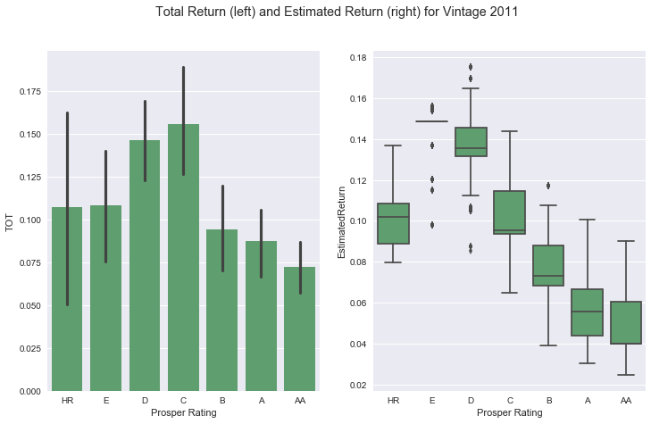

```
3263 number of closed loans
4222 number of total loans
77.0 % of loans are closed already.
37 months term to maturity(average)
27.7 million USD nominal amount.
6559 USD average loan size.
```

```python
tot_by_rating_vintage(Vintage2011_filter, 'Vintage 2011', sb.color_palette()[1])
print(Vintage2011_filter.ClosedDate.count(), 'number of closed loans')
print(Vintage2011_filter.shape[0],'number of total loans')
print((round(Vintage2011_filter.ClosedDate.count() / Vintage2011_filter.shape[0],2)*100),'% of loans are closed already.')
print((round(Vintage2011_filter.Term.mean(),)),'months term to maturity(average)')
print(round(Vintage2011_filter.LoanOriginalAmount.sum()/1000000,1),'million USD nominal amount.')
print(round(Vintage2011_filter.LoanOriginalAmount.mean(),),'USD average loan size.')
```

### The 2011 loan vintage

The total return for the 2011 vintage is highest for rating classes `C` and `D` at approx. 15%. The lower rating classes `E` and `HR` generated more than 10% total return, while top rated `AA` loans generated approx. 7.5% so far. Volatility increases with lower credit quality, with `HR` loans showing the highest and `AA` loans the lowest. Presumably, with interest rates being tightly fixed most of the volatility of total return is caused by credit impairments.

**The distribution of Estimated Returns are reasonable guides for investment performance**. For example, the median estimated return for high risk `HR` loans is 10% (ex-ante) and the realized average total return is at that level.

We can use the Sharpe Ratio to approximate risk adjusted returns:

$SharpeRatio = \frac{Rp - Rf}{σp}$

where: **Rp**=return of portfolio **Rf**=risk-free rate **σp**=standard deviation of the portfolio’s excess return

We set Rp=total return of rating class and we set Rf=0

$SharpeRatio = \frac{TOT Rating}{σTOT}$

**In 2011, rating classes `C` and `D` have the highest Sharpe Ratios** In contrast, the rating classes `E` and `HR` appear unattractive in risk adjusted return terms.

Let us now look at the 2012 vintage.

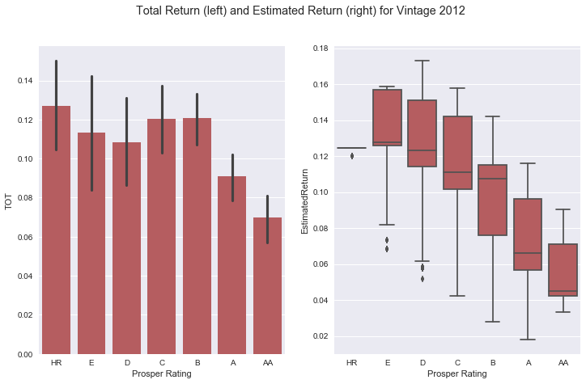

```
4524 number of closed loans
9496 number of total loans
48.0 % of loans are closed already.
42 months term to maturity(average)
71.1 million USD nominal amount.
7485 USD average loan size.
```

```python
tot_by_rating_vintage(Vintage2012_filter, 'Vintage 2012', sb.color_palette()[2])
print(Vintage2012_filter.ClosedDate.count(), 'number of closed loans')
print(Vintage2012_filter.shape[0],'number of total loans')
print((round(Vintage2012_filter.ClosedDate.count() / Vintage2012_filter.shape[0],2)*100),'% of loans are closed already.')
print((round(Vintage2012_filter.Term.mean(),)),'months term to maturity(average)')
print(round(Vintage2012_filter.LoanOriginalAmount.sum()/1000000,1),'million USD nominal amount.')
print(round(Vintage2012_filter.LoanOriginalAmount.mean(),),'USD average loan size.')
```

### The 2012 loan vintage

About half of the loans in the 2012 vintage have closed already. The credit impairment rate is at 13.2% so far, and another 4.5% of loans in this vintage are past due. This could significantly increase impairments soon. **In 2012, rating classes `B` and `C` have the highest Sharpe Ratios (so far).**

It is worth noting that both the average term (42 months ins 2012) and the average loan amount keep increasing from approx. 7,500 USD in 2012 compared to USD 4,400 in 2010, indicating a **loose credit environment**. Loose credit is the practice of making credit easy to come by, and Borrowers feel increasingly confident to get higher loan amounts and longer loan durations funded at Prosper Marketplace.

Let us look at the 2013 vintage now. Only 15% of the loans have closed already, making final investment results difficult to predict. Credit impairments a in this vintage are still below 1%. However, we can highlight recent trends.

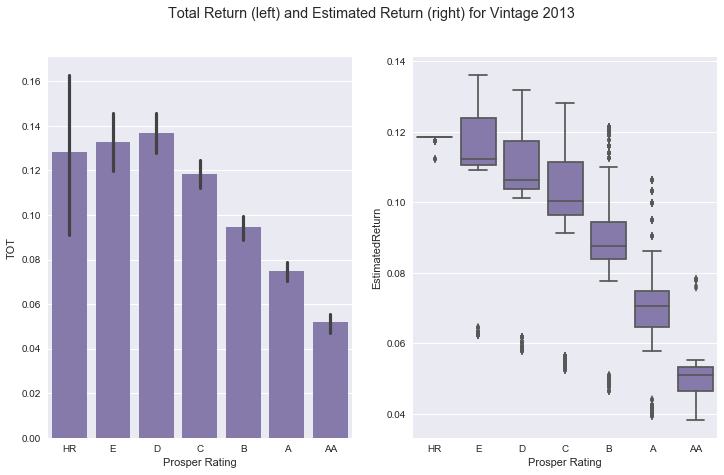

```
1655  number of closed loans
10715 number of total loans
15.0  % of loans are closed already.
46 months term to maturity(average)
106.7 million USD nominal amount.
9960 USD average loan size.
```

```python
tot_by_rating_vintage(Vintage2013_filter, 'Vintage 2013', sb.color_palette()[3])
print(Vintage2013_filter.ClosedDate.count(), ' number of closed loans')
print(Vintage2013_filter.shape[0],'number of total loans')
print((round(Vintage2013_filter.ClosedDate.count() / Vintage2013_filter.shape[0],2)*100),' % of loans are closed already.')
print((round(Vintage2013_filter.Term.mean(),)),'months term to maturity(average)')
print(round(Vintage2013_filter.LoanOriginalAmount.sum()/1000000,1),'million USD nominal amount.')
print(round(Vintage2013_filter.LoanOriginalAmount.mean(),),'USD average loan size.')
```

### The 2013 loan vintage

Let us look at the 2013 vintage now. Only 15% of the loans have closed already, making final investment results difficult to predict. Credit impairments in this vintage are still below 1%. However, we can highlight recent trends.

Total return increases from approx. 5% for `AA` to a peak of almost 14% for `D`. The two lowest rating classes `E` and `HR` show lower average returns, presumably because most of the defaults and charged-offs have happened here. Correspondingly, `E` and `HR`s have much higher standard deviations than higher rating classes, making them less attractive in risk adjusted return terms.

**In 2013, the rating classes `C` and `D` have the highest Sharpe Ratios (so far).**

Let us briefly look at the most recent vintage 2014.

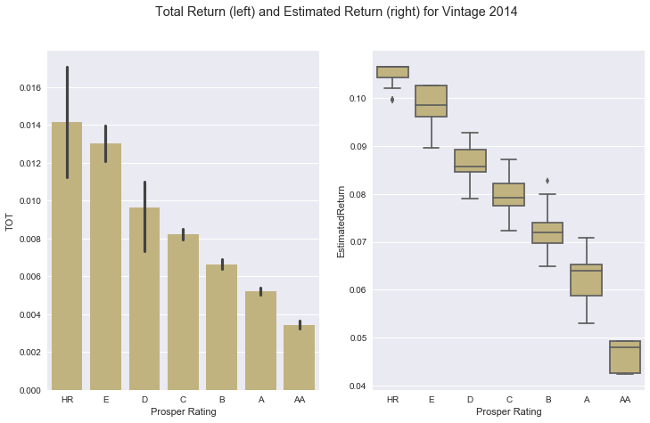

```
68  number of closed loans
11734 number of total loans
1.0  % of loans are closed already.
44 months term to maturity(average)
140.0 million USD nominal amount.
11927 USD average loan size.
```

```python
tot_by_rating_vintage(Vintage2014_filter, 'Vintage 2014', sb.color_palette()[4])
print(Vintage2014_filter.ClosedDate.count(), ' number of closed loans')
print(Vintage2014_filter.shape[0],'number of total loans')
print((round(Vintage2014_filter.ClosedDate.count() / Vintage2013_filter.shape[0],2)*100),' % of loans are closed already.')
print((round(Vintage2014_filter.Term.mean(),)),'months term to maturity(average)')
print(round(Vintage2014_filter.LoanOriginalAmount.sum()/1000000,1),'million USD nominal amount.')
print(round(Vintage2014_filter.LoanOriginalAmount.mean(),),'USD average loan size.')
```

### The 2014 loan vintage (Q1)

The distribution of **Estimated Returns** encourages risk taking, showing increasing return expectation for lower credit quality.

Finally, let us create heatmaps showing the frequency of total return by rating for each quarter. Let us start in 2009 with the introduction of the ProsperRating.

```python
ProsperRating_filter = loan_master[loan_master.CreditGrade != loan_master.CreditGrade] # create a filter
CreditGrade_filter   = loan_master[loan_master.CreditGrade == loan_master.CreditGrade] # create a filter
```

```python
def hist2dgridToT(x, y, **kwargs):
    """ Quick hack for creating heat maps with seaborn's PairGrid. """
    palette = kwargs.pop('color')
    bins_x = np.arange(1, 8, 1)
    bins_y = np.arange(-1.0,0.5, 0.1)
    plt.hist2d(x, y, bins = [bins_x, bins_y], cmap = palette, cmin = 0.5)
```

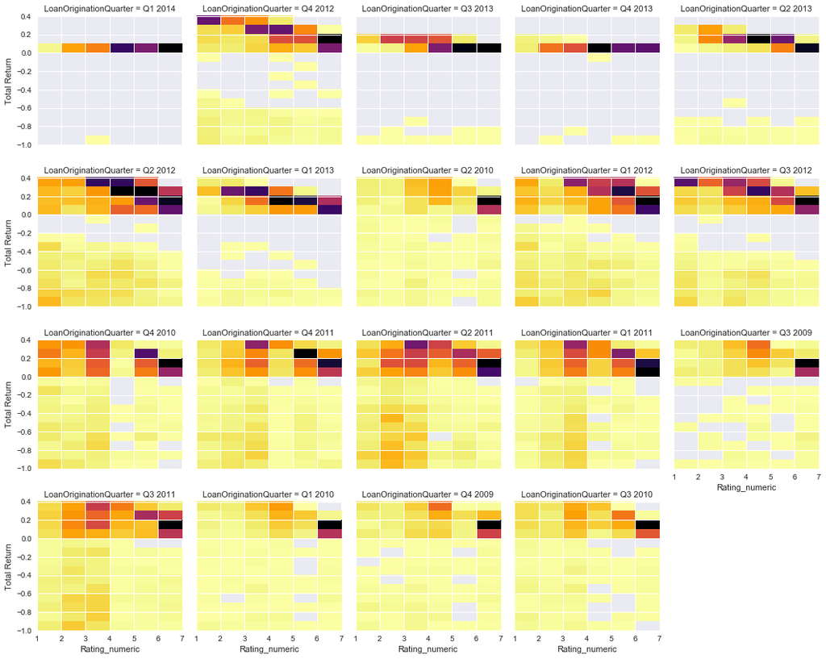

```python
# create faceted heat maps on levels of the Loan Origination Quarter variable
g = sb.FacetGrid(data = ProsperRating_filter, col = 'LoanOriginationQuarter', col_wrap = 5, size = 3, xlim = [0,10])
g.map(hist2dgridToT, 'Rating_numeric', 'TOT', color = 'inferno_r')
g.set_xlabels('Rating_numeric')
g.set_ylabels('Total Return')

plt.show()
```

### The Break-down of Total Return Quarter-by-Quarter (post 2009)

</font>`N/A`= 0 , `HR`= 1 , `E`= 2 , `D`= 3 , `C`= 4 , `B`= 5 , `A`= 6 , `AA`= 7 **( ProsperRating )**

Most quarters show this pattern of higher frequencies of higher rated loans, albeit with some variation. We can gauge the development of credit quality and portfolio performance QUARTER-BY-QUARTER from this headmaps. The amorization create strong cash flows and they lead to lower loss-given-defaults (and chargedoffs) over time. Consequently, older vintages show an increasing number of chargedoff loans with moderate losses. Simultaniously, performing loans keep accummulating income and principal repayment.

However, we have to keep in mind that the macroeconomic environment was favourable during those years. Let us look at the heatmaps of loans issued in quarters before and during the financial crisis.

```python
def hist2dgridToT2(x, y, **kwargs):
    """ Quick hack for creating heat maps with seaborn's PairGrid. """
    palette = kwargs.pop('color')
    bins_x = np.arange(8, 16, 1)
    bins_y = np.arange(-1.0,0.5, 0.1)
    plt.hist2d(x, y, bins = [bins_x, bins_y], cmap = palette, cmin = 0.5)
```

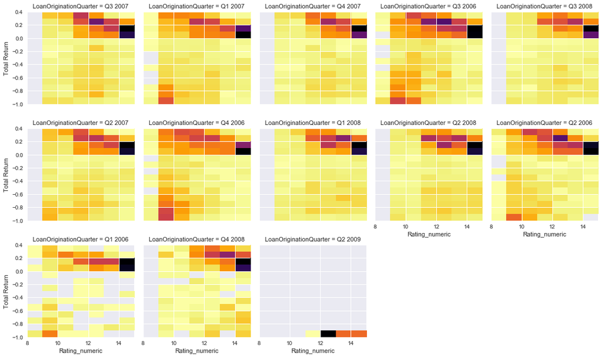

```python
# create faceted heat maps on levels of the Loan Origination Quarter variable
g = sb.FacetGrid(data = CreditGrade_filter, col = 'LoanOriginationQuarter', col_wrap = 5, size = 3, xlim = [0,10])
g.map(hist2dgridToT2, 'Rating_numeric', 'TOT', color = 'inferno_r')
g.set_xlabels('Rating_numeric')
g.set_ylabels('Total Return')

plt.show()
```

### The Break-down of Total Return Quarter-by-Quarter (before 2009)

</font>`nc`= 8 , `hr`= 9,`e`= 10,`d`= 11 ,`c`= 12 ,`b`= 13 ,`a`= 13 ,`aa`= 14 **( CreditGrade)**

Prosper's performance track-record for loans issued until 2008 reflects its flowed business model at the time. The average **Total Return** for 2006, 2007 and 2008 are -4.5%, -10.4% and - 3.0%, respectively.

We have learned that information about borrowers' **Employment Status** and **Income** was sketchy before the SEC registration. Furthermore, a minimum FICO 8 credit score of at least 640 for new borrowers was only introduced in 2009. The heatmaps provide valuable inside about the consequences of a severe macro-economic shock on unsecured loans from vulnerable borrowers. In particular, there is a very high frequency of defaults and charged-offs for low rated borrowers `e`= 10 and `nr`= 9.

```python
loan_master.to_csv(r'loan_master_TOT.csv', index=True)
```

### Talk about some of the relationships you observed in this part of the investigation. Were there features that strengthened each other in terms of looking at your feature(s) of interest?

> Both the rating methodology and the rate setting mechanism used by Prosper before 2009 were fundamentally flawed, leading to an overestimation of credit quality and a mispricing of risk. Consequently, all scales of the CreditGrade spectrum experience an almost equal number of charged-offs and the distribution of interest rates for CreditGrade scales overlap. In comparison, the number of charged-offs for the new ProsperRating concentrate on the low rating classes ‘HR’, ‘E’ and ‘D’ and interest rate distributions do not overlap as much.

We have defined the variables **Profit and Loss** (**P&L**) and **Total Return**(**TOT**) to evaluate the impact of defaults and charged-offs on investors' return. For performing loans, the P&L and TOT is predefined by the loan amount, the interest rate and the term to maturity. High interest rates on Prosper loans suggest attractive investment returns. However, the realized loss on charged-off and defaulted loans is -50% of principal and more. Therefore, reducing the likelihood of credit impairments is the best way to improve the portfolio return.

We have looked at the rate of credit impairments (i.e. defaults and charged-offs) by rating and by calendar year. Credit impairment rates were highest for loans issued before 2009 (i.e. Vintage 2006, 2007 and 2008). While the default rates have kept low thereafter, the rate of charged-offs has picked-up again. Both defaults and charged-offs have a similar negative impact on investors total return, and we should treat them the same.

We have looked at the **ex-ante Expected Loss** issued by Prosper and the **realized Total Return** by rating for the loan vintage years 2010-2013. The expected return by rating is a rough indicator of realized total return, typically overstating the annualized investment return by a high margin. The annualized return in Prosper's best performing vintage year, 2010, were approx. 2% for `AA`, 4.7% for `C` and `D`, 7.1% for `E` and 6.8% for `HR`. However, charged-offs have picked-up again and rates keep coming down. **A credit impairment rate of 15-20% per vintage year should be expected in normal times, and an economic downturn can lead to a sharp increase**.

### Were there any interesting or surprising interactions between features?

The annualized return in Prosper's best performing vintage year, 2010, were approx. 2% for `AA`, 4.7% for `C` and `D`, 7.1% for `E` and 6.8% for `HR`. However, charged-offs have picked-up again and rates keep coming down. **A credit impairment rate of 15-20% per vintage year should be expected in normal times, and an economic downturn can lead to a sharp increase**.

For most vintage years, the medium credit quality ratings `B`, `C` and `D` have the most attractive risk-adjusted profile. Loans from borrowers of lower quality `E` and high risk `HR` have generated similar or even lower total returns in 2011-2013 vintages so far, but with a much higher volatility, making 'stock picking' very dangerous. Given the idiosyncratic risk, a high diversification with 100+ loans in a portfolio is advisable for investments in Prosper loans (e.g. USD 50-100 each). Investors should allocate to high rating classes `AA`and `A` as well to improve the quality mix of the portfolio. By applying these guidelines an investment return of **approx. 5% p.a.** can be expected for a well-diversified portfolio. However, economic downturns could significantly reduce the performance. We have looked at the relationship between the variables **Employment Status** and **Income Range** and credit impairment rates. The categories can serve as indicators for credit risk. A very low or very high income is a good predictor of increased credit impairment risk. An Employment Status of `Employed` signals the lowest risk of delinquencies while a status of `Self-employed` is significantly riskier.